# A Quick Introduction to iNEXT.link via Examples

Anne Chao, Kai-Hsiang Hu, K.W. Chen, C.G. Lo, S.Y. Wang

2024-05-30

`iNEXT.link` is an R package that extends the concepts of `iNEXT.3D` (Chao et al., 2021), `iNEXT.4step` (Chao et al., 2020) and `iNEXT.beta3D` (Chao et al., 2023) to ecological networks (Chiu et al., 2023). In this document, we provide a brief overview of `iNEXT.link` and its functionalities. Detailed information about the `iNEXT.link` functions can be found in the `iNEXT.link` manual, which is also available on [Github](https://github.com/AnneChao). For users without an R background, an online version (https://chao.shinyapps.io/iNEXT_link/) of `iNEXT.link` is also available.

Chiu et al. (2023) adapted the unified 3D-diversity framework of Chao et al. (2021) to ecological networks, and generalized the previous diversity measures to the following three dimensions of network diversity (3D network diversity) for interaction data:

1. Taxonomic network diversity that incorporates interaction richness and evenness among the strength (or frequency) of interactions.
2. Phylogenetic network diversity that additionally considers species’ phylogeny.
3. Functional network diversity that additionally accounts for species’ traits.

iNEXT.link adapts iNEXT, iNEXT.3D, and iNEXT.4steps to quantify and estimate 3D network diversity based on incomplete sampling data. It also adapts iNEXT.beta3D to assess network alpha, beta and gamma diversity as well as the associated (dis)similarity measures. For the former adaption, the iNEXT.link methodology integrates the following four inference procedures:

**Step 1: Assessment of network completeness profiles**

The sample completeness of a network is characterized by profile depicting the sample completeness (developed in Chiu et al. 2023) with respect to an order q ≥ 0. When q = 0, the completeness measure reduces to (an upper bound) of the proportion of the observed interaction richness relative to an estimated interaction richness. When q = 1, the completeness measure reduces to the network-version sample coverage (the proportion of the total number of interaction events that belong to detected ones). When q ≥ 2, the completeness measure is disproportionally sensitive to highly frequent interactions. The proposed profile allows for tuning the effect of interaction frequency on the sample completeness. For a complete network (i.e., there are no undetected interactions), the estimated sample completeness profile will be a horizontal line at the level of unity for all orders of q  0. In contrast, for an incomplete network, the sample completeness profile will be an increasing function of order q.

**STEP 2. Sample-size- or size-based rarefaction and extrapolation analysis with 3D network diversity for q = 0, 1, and 2, and the asymptotic network diversity profile. Here “size” means the number of interaction events.**

**(STEP 2a)** For each dimension of the 3D network diversity, first examine the pattern of the size-based rarefaction and extrapolation sampling curve up to double the reference sample size for q = 0, 1 and 2. If the curve stays at a fixed level (this often occurs for the measures of q = 1 and 2), then the asymptotic network-diversity estimate presented in the next step (Step 2b) can be used to accurately infer the true network diversity. Otherwise, the asymptotic diversity estimate represents only a lower bound (this often occurs for the measure of q = 0).

**(STEP 2b)** When the true network diversity can be accurately inferred, the extent of undetected diversity within each dataset is obtained by comparing the estimated asymptotic diversity profile and empirical profile; the difference in the network diversity can be evaluated and tested for significance.

**STEP 3. Non-asymptotic coverage-based rarefaction and extrapolation analysis with 3D network diversity for orders q = 0, 1 and 2**

When sampling data do not contain sufficient information to accurately infer true network diversity based on asymptotic estimates, meaningful comparisons of 3D network diversity across multiple datasets should be made by standardizing the sample coverage. This comparison can be done by seamlessly integrating coverage-based rarefaction and extrapolation sampling curves with each dimension of network diversity up to a maximum coverage (C_max = the level of coverage reached by the extrapolated sample that attains the lowest coverage when all samples are extrapolated to double the reference sample sizes).

**STEP 4. Assessment of network unevenness (i.e., specialization) profiles**

The five classes of unevenness measures developed in Chao and Ricotta (2019) are used to measure network specialization. Each unevenness measure is parameterized by an order q > 0; for q = 0, interaction frequencies are disregarded, so it is not meaningful to evaluate (un)evenness among frequencies. For each class, one can construct a continuous profile that depicts the measure as a function of diversity order q > 0. All five classes are functions of taxonomic network diversity and interaction richness. Because interaction richness often cannot be accurately estimated for incomplete sampling data, unevenness/specialization profiles across networks can only be compared at a standardized coverage level, up to a maximum coverage value of C_max, defined in Step 3.

The following step was not included in the proposed procedure in Chiu et al. (2023), but is featured in this R package.

**STEP 5. Beta diversity and dissimilarity among networks**

For each dimension of 3D network diversity, iNEXT.link also features standardized 3D network-diversity estimates with a common sample size (for alpha and gamma diversity) or sample coverage (for alpha, beta and gamma diversity). iNEXT.link also features standardized estimates of four classes of coverage-based dissimilarity measures. The corresponding rarefaction and extrapolation sampling curves are also provided.

NOTE 1: Sufficient data are required to perform the `iNEXT.link` data analysis. If there are only a few interaction events in the user’s data, it is likely that the data are too sparse to use `iNEXT.link`.

NOTE 2: STEPS 1 to 4 aim to compare within-network diversity. If the goal is to assess the extent of similarity or differentiation among networks, users should use STEP 5. The details of STEP 5 are omitted; users are referred to the user’s guide of `iNEXT.beta3D`, available at https://chao.shinyapps.io/iNEXT_beta3D, for all procedures; see Chao et al. (2023) for pertinent methodology.

## HOW TO CITE iNEXT.link

If you publish your work based on the results from the `iNEXT.link` package, you should cite the following methodology paper (Chiu et al., 2023):

- Chiu, C-H., Chao, A., Vogel, S., Kriegel, P. and Thorn, S. (2023). Quantifying and estimating ecological network diversity based on incomplete sampling data. Philosophical Transactions of the Royal Society B, 378: 20220183. https://doi.org/10.1098/rstb.2022.0183

## SOFTWARE NEEDED TO RUN iNEXT.link IN R

- Required: [R](https://cran.r-project.org/)
- Suggested: [RStudio IDE](https://posit.co/products/open-source/rstudio/#Desktop)

## HOW TO RUN iNEXT.link:

The `iNEXT.link` package can be downloaded from Anne Chao’s [iNEXT.link_github](https://github.com/AnneChao/iNEXT.link) using the commands below. For a first-time installation, an additional visualization extension package (`ggplot2`) from CRAN and (`iNEXT.3D`), (`iNEXT.4steps`), and (`iNEXT.beta3D`) from Anne Chao’s github must be installed and loaded.

```r
## install iNEXT.link package from CRAN
# install.packages("iNEXT.link")  # coming soon

## install the latest version from github
install.packages('devtools')
library(devtools)

# install_github('AnneChao/iNEXT.3D')
# install_github('AnneChao/iNEXT.4steps')
# install_github('AnneChao/iNEXT.beta3D')

install_github('AnneChao/iNEXT.link')

## import packages
library(iNEXT.link)
```

There are twelve main functions in this package:

Two functions for non-asymptotic analysis with graphical displays:

- **iNEXT.link** Computes rarefaction/extrapolation taxonomic, phylogenetic, and functional network diversity estimates for q = 0, 1 and 2 for rarefied and extrapolated samples at specified sample sizes and sample coverage/completeness estimates.
- **ggiNEXT.link** visualizes the output from the function `iNEXT.link`

Two functions for point estimation and basic data information

- **estimateD.link** computes 3D network diversity of q = 0, 1 and 2 with a particular user-specified level of sample size or sample coverage/completeness values.
- **DataInfo.link** provides basic data information based on the observed data.

Two functions for asymptotic analysis with graphical displays:

- **ObsAsy.link** computes observed and asymptotic network diversity of order q between 0 and 2 (in increments of 0.2) for 3D network diversity; it also computes observed and asymptotic qiPD for specified reference times, and observed and asymptotic qiFD for specified threshold levels.
- **ggObsAsy.link** visualizes the output from the function `ObsAsy.link`

Two functions for completeness analysis with graphical displays:

- **Completeness.link** calculates estimated sample completeness with order q.
- **ggCompleteness.link** visualizes the output from the function `Completeness.link`

Two functions for specialization analysis with graphical displays:

- **Spec.link** computes standardized specialization estimation under specified sample coverage(or observed) with order q.
- **ggSpec.link** visualizes the output from the function `Spec.link`

Two functions for alpha, beta, gamma network diversity analysis and dissimilarity analysis with graphical displays:

- **iNEXTbeta.link** computes standardized gamma, alpha, beta network diversity, and four dissimilarity-turnover indices for three dimensions: taxonomic, phylogenetic and functional diversity at specified sample coverage.
- **ggiNEXTbeta.link** visualizes the output from the function `iNEXTbeta.link`

## DATA INPUT FORMAT

### Species interaction frequency data format

Information on shared/unique species and their abundances is required. Thus, species identity (or any unique identification code) and assemblage affiliation must be provided in the data. Input data for a single dataset with N assemblages consist of a species-by-assemblage abundance `matrix/data.frame`. Users can input several datasets which may represent data collected from various localities, regions, plots, time periods, …, etc. Input data for multiple datasets then consist of a list of matrices; each matrix represents a species-by-assemblage abundance matrix for one of the datasets. Different datasets can have different numbers of assemblages. `iNEXTbeta3D` computes beta diversity and dissimilarity among assemblages within each dataset.

For example, the dataset `beetles_plotA` included in the `iNEXT.link` package consists of a list of two matrices (for two fragments named “Closed” and “Open”, respectively); each matrix represents a species-by-species interaction matrix. Run the following code to view the data: (Here we only show the first 4 columns for each matrix.).

```r
data(beetles_plotA)
beetles_plotA
```

```
#> $Closed
#>                  Acrulia_inflata Ampedus_pomorum Ampedus_sanguineus Anaspis_flava
#> Populus_tremula                0               0                  0             0
#> Quercus_petraea                0               1                  0             0
#> Carpinus_betulus               1               2                  0             0
#> Pinus_sylvestris               0               0                  1             1
#> Fagus_sylvatica                0               0                  0             0
#> Abies_alba                     1               0                  1             1
#>
#> $Open
#>                  Agrilus_olivicolor Ampedus_sanguineus Anaspis_flava Anaspis_thoracica
#> Populus_tremula                   0                  0             1                 0
#> Quercus_petraea                   0                  0             1                 0
#> Carpinus_betulus                  0                  0             0                 0
#> Pinus_sylvestris                  0                  2             0                 0
#> Fagus_sylvatica                   1                  1             0                 1
#> Abies_alba                        0                  0             0                 0
```

### Phylogenetic tree for phylogenetic network diversity

To conduct phylogenetic network diversity analysis, the phylogenetic tree (in Newick format) spanned by species observed in all datasets must be stored in a data file. For example, the phylogenetic tree for all observed species (including species in “Closed” and “Open” fragments) is stored in a data file named `"beetles_col_tree"` for demonstration purpose. A partial list of the tip labels and node labels are shown below.

```r
data(beetles_col_tree)
beetles_col_tree
```

```
#>
#> Phylogenetic tree with 1449 tips and 757 internal nodes.
#>
#> Tip labels:
#>   Neuroptera, Tachyta_nana, Rhysodes_sulcatus, Omoglymmius_germari, Teretrius_fabricii, Plegaderus_saucius, ...
#> Node labels:
#>   match0, match1, match2, match3, match4, match5, ...
#>
#> Rooted; includes branch lengths.
```

### Species pairwise distance matrix for functional network diversity

To compute functional network diversity, the species-pairwise distance matrix (Gower distance computed from species traits) for species observed in all datasets must be stored in a matrix/data.frame format. Typically, the distance between any two species is computed from species traits using the Gower distance. In our demo data, the distance matrix for all species (including species in “Closed”, and “Open” fragments) is stored in a data file named `"beetles_col_distM"` for demonstration purpose. Here we only show the first three rows and three columns of the distance matrix.

```r
data(beetles_col_distM)
beetles_col_distM
```

```
#>                       Tachyta_nana Plegaderus_vulneratus Plegaderus_caesus
#> Tachyta_nana                 0.000                 0.203             0.243
#> Plegaderus_vulneratus        0.203                 0.000             0.222
#> Plegaderus_caesus            0.243                 0.222             0.000
```

## SINGLE COMMUNITY FUNCTION: iNEXT.link()

We first describe the main function `iNEXT.link()` with default arguments:

```r
iNEXT.link(data,diversity = "TD", q = c(0, 1, 2), size = NULL, nT = NULL,
           endpoint = NULL, knots = 40, conf = 0.95, nboot = 30,
           row.tree = NULL, col.tree = NULL, PDtype = "meanPD",
           row.distM = NULL, col.distM = NULL, FDtype = "AUC", FDtau = NULL)
```

The arguments of this function are briefly described below, and will be explained in more details by illustrative examples in later text. This main function computes standardized 3D network diversity estimates of order q = 0, 1 and 2, the sample coverage estimates, and related statistics for K (if `knots = K` in the specified argument) evenly-spaced knots (sample sizes) between size 1 and the `endpoint`, where the endpoint is described below. Each knot represents a particular sample size for which 3D network diversity estimates will be calculated. By default, `endpoint` = double the reference sample size for interaction frequency data. For example, if `endpoint = 10`, `knot = 4` is specified, diversity estimates will be computed for a sequence of samples with sizes (1, 4, 7, 10).

| Argument | Description |
| --- | --- |
| `data` | a list of `data.frames`, each `data.frames` represents col.species-by-row.species abundance matrix. |
| `diversity` | selection of diversity type: `TD` = Taxonomic network diversity, `PD` = Phylogenetic network diversity, and `FD` = Functional network diversity. |
| `q` | a numerical vector specifying the diversity orders. Default is `c(0, 1, 2)`. |
| `size` | an integer vector of sample sizes (number of interaction events) for which network diversity estimates will be computed. If NULL, then network diversity estimates will be computed for those sample siz… |
| `endpoint` | an integer specifying the sample size that is the endpoint for rarefaction/extrapolation. If NULL, then endpoint = double reference sample size. |
| `knots` | an integer specifying the number of equally-spaced `knots` (say K, default is 40) between size 1 and the `endpoint`; each knot represents a particular sample size for which network diversity estimate … |
| `conf` | a positive number < 1 specifying the level of confidence interval. Default is 0.95. |
| `nboot` | a positive integer specifying the number of bootstrap replications when assessing sampling uncertainty and constructing confidence intervals. Enter 0 to skip the bootstrap procedures. Default is 30. |
| `row.tree` | (argument only for diversity = “PD” a phylogenetic tree of row assemblage in the pooled network row assemblage. |
| `col.tree` | (argument only for diversity = “PD”) a phylogenetic tree of column assemblage in the pooled network column assemblage. |
| `PDtype` | (argument only for diversity = “PD”) select PD type: PDtype = “PD” (effective total branch length) or PDtype = “meanPD” (effective number of equally divergent lineages). Default is “meanPD”, where mea… |
| `row.distM` | (argument only for diversity = “FD”) a species pairwise distance matrix for all species of row assemblage in the pooled network row assemblage. |
| `col.distM` | (argument only for diversity = “FD”) a species pairwise distance matrix for all species of column assemblage in the pooled network column assemblage. |
| `FDtype` | (argument only for diversity = “FD”), select FD type: FDtype = “tau_values” for FD under specified threshold values, or FDtype = “AUC” (area under the curve of tau-profile) for an overall FD which int… |
| `FDtau` | (argument only for diversity = “FD” and FDtype = “tau_values”), a numerical vector between 0 and 1 specifying tau values (threshold levels). If NULL (default), then threshold is set to be the mean dis… |

For each dimension of network diversity (`TD`, `PD`, `FD`), the main function `iNEXT.link()` returns the `iNEXT.link` object, which can be further used to make plots using the function `ggiNEXT.link()` to be described below. The `"iNEXT.link"` object includes three lists:

1. `$TDInfo` (`$PDInfo`,or `$FDInfo`) for summarizing data information.
2. `$TDiNextEst` (`$PDiNextEst`, or `$FDiNextEst`) for showing network diversity estimates along with related statistics for a series of rarefied and extrapolated samples; there are two data frames (`$size_based` and `$coverage_based`) conditioning on standardized sample size or sample coverage, respectively.
3. `$TDAsyEst` (`$PDAsyEst`, or `$FDAsyEst`) for showing asymptotic network diversity estimates along with related statistics.

## FUNCTION ggiNEXT.link(): GRAPHIC DISPLAYS

The function `ggiNEXT.link()`, which extends `ggplot2` with default arguments, is described as follows:

```r
ggiNEXT.link(output, type = c(1, 2, 3), facet.var = "Assemblage", color.var = "Order.q")
```

Here `output` is the `ggiNEXT.link()` object. Three types of curves are allowed for 3D diversity:

1. Sample-size-based R/E curve (`type = 1`): This curve plots network diversity estimates with confidence intervals as a function of sample size.
2. Sample completeness curve (`type = 2`): This curve plots the sample coverage/completeness with respect to sample size.
3. Coverage-based R/E curve (`type = 3`): This curve plots the network diversity estimates with confidence intervals as a function of sample coverage.

The argument `facet.var = "Order.q"`, `facet.var = "Assemblage"`, `facet.var = "Both"`, or `facet.var = "None"` is used to create a separate plot for each value of the specified variable.

The `ggiNEXT.link()` function is a wrapper with the package `ggplot2` to create a rarefaction/extrapolation sampling curve in a single line of code. The figure object is of class `"ggplot"`, so it can be manipulated by using the `ggplot2` tools.

## TAXONOMIC NETWORK DIVERSITY (qiTD): RAREFACTION/EXTRAPOLATION VIA EXAMPLES

### EXAMPLE 1: qiTD rarefaction/extrapolation for interaction frequency data

Based on the dataset (`beetles_plotA`) included in the package, the following commands return all numerical results for `TD`. The first list of the output (`$TDInfo`) returns basic data information including the name of the Assemblage(`Dataset`), number of observed interaction events in the reference sample (`n`), number of observed species in row assemblage (`S.obs(row)`), number of observed species in column assemblage (`S.obs(col)`), number of observed interactions in the reference sample (`Link.obs`), the proportion of links between species that are realized in the network matrix (`Connectance`), estimator of the sample coverage of the reference sample (`Coverage`) as well as the first ten species interaction frequency counts in the reference sample (`f1-f10`). The output is identical to that based on the function `DataInfo.link()` by specifying `diversity = 'TD'`; see later text). Thus, if only data information is required, the simpler function `DataInfo.link()` (see later text) can be used to obtain the same output. More information about the observed diversity (for any order q between 0 and 2) can be obtained by function `ObsAsy.link()`, which will be introduced later.

```r
data(beetles_plotA)
data <- beetles_plotA
output_qiTD = iNEXT.link(data, diversity = 'TD', q = c(0,1,2), nboot = 30)
output_qiTD$TDInfo
```

```
#>   Dataset    n S.obs(row) S.obs(col) Links.obs Connectance Coverage  f1 f2 f3 f4 f5 f6 f7 f8 f9 f10
#> 1  Closed  816          6         83       178       0.357    0.880  98 31 15  3  3  5  0  2  2   1
#> 2    Open 1932          6         88       206       0.390    0.943 110 33 15  8  7  5  3  2  3   2
```

The second list of the output (`$TDiNextEst`) includes size- and coverage-based standardized network diversity estimates and related statistics computed for 40 knots by default (for example in the “Closed” assemblage, corresponding to the target sample size `m` = 1, 43, 86, …, 730, 773, 816, 817, 859, …, 1632), which locates the reference sample size at the mid-point of the selected knots. There are two data frames (`$size_based` and `$coverage_based`).

The first data frame (`$size_based`) includes the name of the Assemblage (`$Dataset`), the network diversity order of q (`Order.q`), the target standardized sample size (`m`), the `Method` (`Rarefaction`, `Observed`, or `Extrapolation`, depending on whether the size `m` is less than, equal to, or greater than the reference sample size), the estimated network diversity of order q for a sample of size `m` (`qiTD`), the bootstrap lower and upper confidence limits for the network diversity of order q (`qiTD.LCL` and `qiTD.UCL`) conditioning on the sample size, and the estimated network coverage for a sample of size `m` (`SC`) along with the bootstrap lower and upper confidence limits for the expected sample coverage (`SC.LCL` and `SC.UCL`). These sample coverage/completeness estimates with confidence intervals are used for plotting the sample completeness curve. If the argument `nboot` is greater than zero, then a bootstrap method is applied to obtain the confidence intervals for the diversity and sample coverage estimates. Otherwise, all confidence intervals will not be computed. Here only the first six rows of the `$size_based` output are displayed:

```r
output_qiTD$TDiNextEst$size_based
```

```
#>   Dataset Order.q   m      Method qiTD qiTD.LCL qiTD.UCL    SC SC.LCL SC.UCL
#> 1  Closed       0   1 Rarefaction  1.0      1.0      1.0 0.029  0.026  0.033
#> 2  Closed       0  43 Rarefaction 28.0     27.0     29.1 0.543  0.515  0.571
#> 3  Closed       0  86 Rarefaction 44.8     42.7     46.9 0.661  0.638  0.684
#> 4  Closed       0 129 Rarefaction 58.2     55.2     61.1 0.713  0.693  0.734
#> 5  Closed       0 172 Rarefaction 69.8     66.0     73.5 0.745  0.726  0.764
#> 6  Closed       0 215 Rarefaction 80.2     75.8     84.7 0.767  0.749  0.786
```

The second data frame (`$coverage_based`) includes the name of assemblage (`Dataset`), the network diversity order of q (`Order.q`), the target standardized sample completeness (`SC`), the corresponding sample size for the standardized completeness (`m`), the `Method` (`Rarefaction`, `Observed`, or `Extrapolation`, depending on whether the coverage/completeness `SC` is less than, equal to, or greater than the reference sample coverage/completeness), the estimated network diversity of order q for the target coverage value (`qiTD`) along with the bootstrap lower and upper confidence limits for the network diversity of order q (`qiTD.LCL` and `qiTD.UCL`) conditioning on the target sample coverage value. Here only the first six rows of the `$coverage_based` output are displayed below: (Note for a fixed coverage value, the confidence interval in the `$coverage_based` table is wider than the corresponding interval in the `$size_based` table. This is because, for a given coverage value, the sample size needed to attain a fixed coverage value varies with bootstrap replication, leading to higher uncertainty on the resulting diversity estimate.)

```r
output_qiTD$TDiNextEst$coverage_based
```

```
#>   Dataset Order.q    SC   m      Method qiTD qiTD.LCL qiTD.UCL
#> 1  Closed       0 0.029   1 Rarefaction  1.0    0.879     1.12
#> 2  Closed       0 0.543  43 Rarefaction 28.0   24.522    31.56
#> 3  Closed       0 0.661  86 Rarefaction 44.8   38.903    50.67
#> 4  Closed       0 0.713 129 Rarefaction 58.2   50.322    65.99
#> 5  Closed       0 0.745 172 Rarefaction 69.8   60.216    79.32
#> 6  Closed       0 0.767 215 Rarefaction 80.2   69.161    91.32
```

The third list of the output (`$TDAsyEst`) includes the name of the Assemblage (`$Dataset`), diversity label (`qiTD`, species richness for q = 0, Shannon diversity for q = 1, and Simpson diversity for q = 2), the observed network diversity (`TD_obs`), asymptotic network diversity estimate (`TD_asy`) and its estimated bootstrap standard error (`s.e.`) as well as the bootstrap lower and upper confidence limits for the asymptotic network diversity estimate of order q (`qiTD.LCL` and `qiTD.UCL`). These statistics are computed only for q = 0, 1 and 2. More detailed information about asymptotic and observed diversity estimates for any order q between 0 and 2 can be obtained from function `ObsAsy.link()`. The output for `$TDAsyEst` is shown below:

```r
output_qiTD$TDAsyEst
```

```
#>   Dataset               qTD TD_obs TD_asy   s.e. qTD.LCL qTD.UCL
#> 1  Closed  Species richness 178.00 332.71 48.593  237.47  427.95
#> 2  Closed Shannon diversity  64.69  80.32  4.242   72.00   88.63
#> 3  Closed Simpson diversity  32.63  33.94  1.745   30.52   37.37
#> 4    Open  Species richness 206.00 389.24 38.597  313.59  464.89
#> 5    Open Shannon diversity  23.31  25.91  1.304   23.36   28.47
#> 6    Open Simpson diversity   8.06   8.09  0.338    7.43    8.75
```

The `ggiNEXT.link` function can be used to make graphical displays for rarefaction and extrapolation sampling curves. When `facet.var = "Assemblage"` is specified in the `ggiNEXT.link` function, it creates a separate plot for each assemblage; within each assemblage, different color curves represent diversity of different orders. An example for showing sample-size-based rarefaction/extrapolation curves (`type = 1`) is given below:

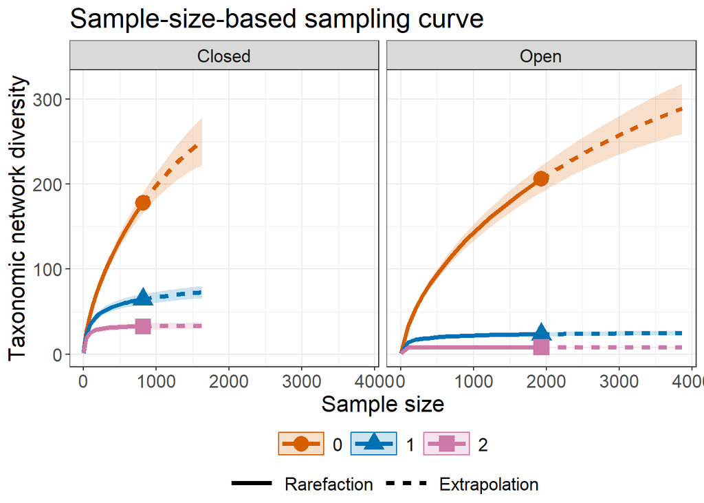

```r
# TD sample-size-based R/E curves, separating by "Assemblage"
ggiNEXT.link(output_qiTD, type = 1, facet.var = "Assemblage")
```

When `facet.var = "Order.q"` is specified in the `ggiNEXT.link` function, it creates a separate plot for each diversity order; within each plot, different color curves represent different assemblages. An example is shown below:

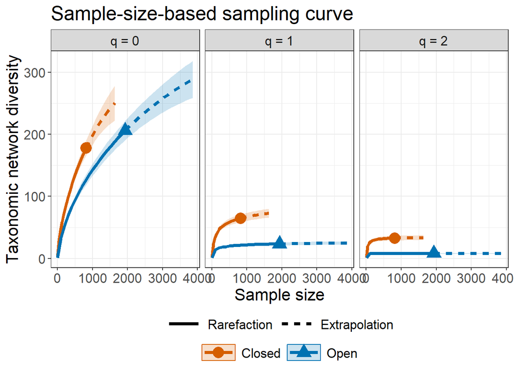

```r
# TD sample-size-based R/E curves, separating by "Order.q"
ggiNEXT.link(output_qiTD, type = 1, facet.var = "Order.q")
```

The following commands return the sample completeness (sample coverage) curve (`type = 2`) in which different colors represent different assemblages.

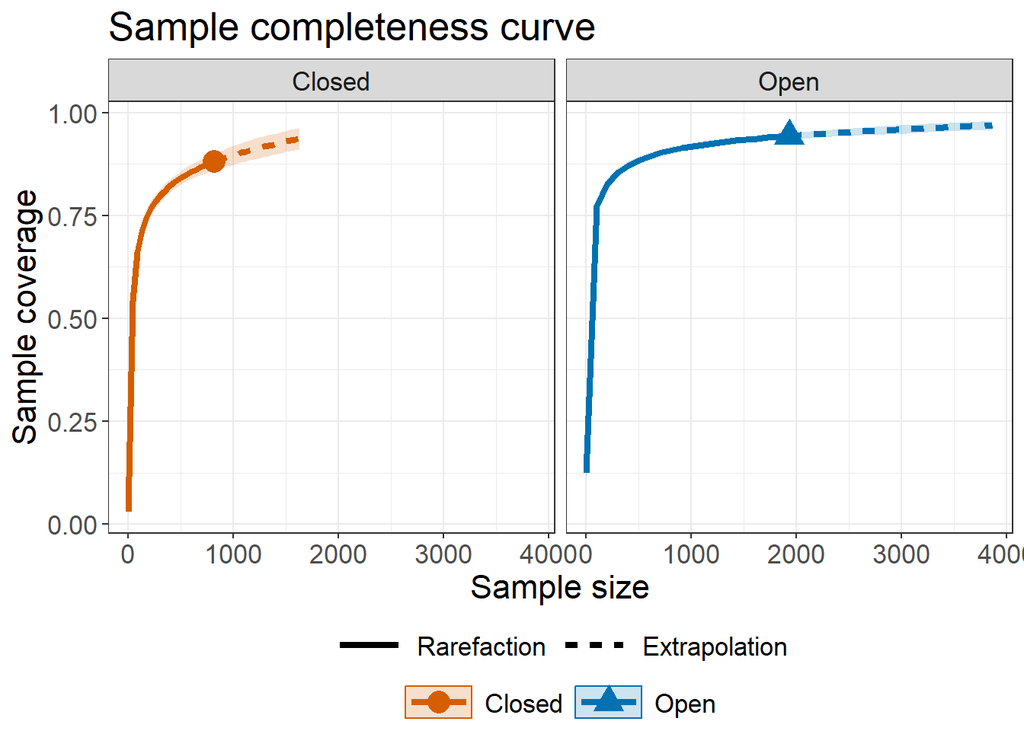

```r
# Sample completeness curves for abundance data, separating by "Assemblage"
ggiNEXT.link(output_qiTD, type = 2, facet.var = "Assemblage")
```

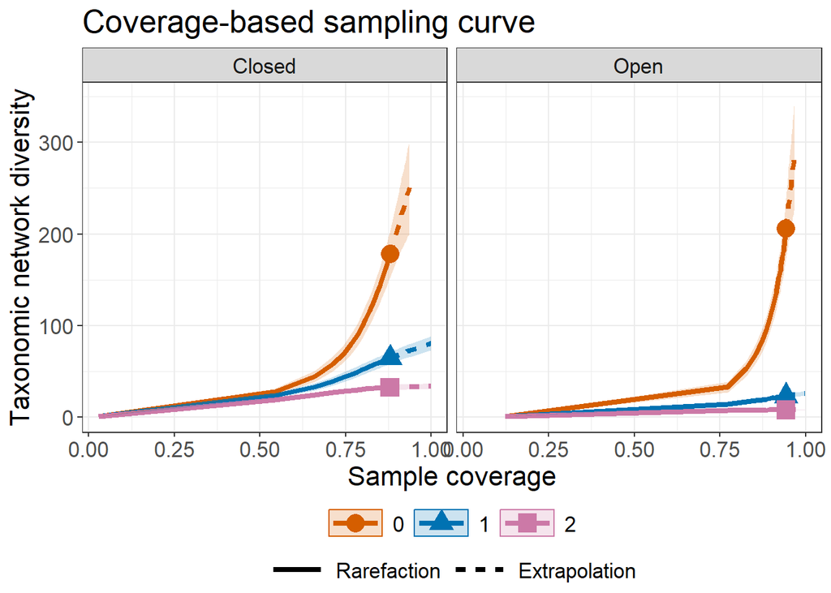

```r
# TD coverage-based R/E curves, separating by "Assemblage"
ggiNEXT.link(output_qiTD, type = 3, facet.var = "Assemblage")
```

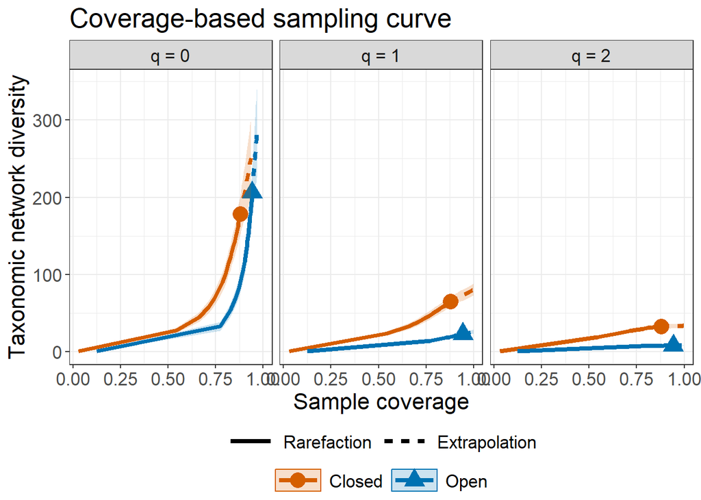

```r
# TD coverage-based R/E curves, separating by "Order.q"
ggiNEXT.link(output_qiTD, type = 3, facet.var = "Order.q")
```

## PHYLOGENETIC NETWORK DIVERSITY (qiPD): RAREFACTION/EXTRAPOLATION VIA EXAMPLES

### EXAMPLE 2: qiPD rarefaction/extrapolation for interaction frequency data

Based on the dataset (`beetles_plotA`) included in the package, the following commands return all numerical results for `PD`. The first list of the output (`$PDInfo`) returns basic data information including the name of the Assemblage(`Dataset`), number of observed interaction events in the reference sample (`n`), number of observed species in row assemblage (`S.obs(row)`), number of observed species in column assemblage (`S.obs(col)`), number of observed interactions in the reference sample (`Link.obs`), the proportion of links between species that are realized in the network matrix(`Connectance`), the number of singletons and doubletons in the node/branch set (`f1*, f2*`), the total branch length of those singletons/doubletons in the node/branch set (`g1, g2`), the observed total branch length in the phylogenetic tree (`PD.obs`) as well as the product of column tree depth and row tree depth (`T1*T2`). The output is identical to that based on the function `DataInfo.link()` by specifying `diversity = 'PD'`; see later text). Thus, if only data information is required, the simpler function `DataInfo.link()` (see later text) can be used to obtain the same output. More information about the observed diversity (for any order q between 0 and 2) can be obtained by function `ObsAsy.link()`, which will be introduced later.

```r
data(beetles_plotA)
data(beetles_col_tree)

data <- beetles_plotA
tree <- beetles_col_tree

output_qiPD  <- iNEXT.link(data, diversity = 'PD', q = c(0, 1, 2), nboot = 20, col.tree = tree)
output_qiPD$PDInfo
```

```
#>   Dataset    n S.obs(row) S.obs(col) Links.obs Connectance f1* f2*    g1   g2 PD.obs T1*T2
#> 1  Closed  816          6         83       178       0.357 171  76 11509 3873    924   285
#> 2    Open 1932          6         88       206       0.390 190  76 13918 5172   1014   285
```

The second list of the output (`$PDiNextEst`) includes size- and coverage-based standardized network diversity estimates and related statistics computed for 40 knots by default (for example in the “Closed” assemblage, corresponding to the target sample size `m` = 1, 43, 86, …, 730, 773, 816, 817, 859, …, 1632), which locates the reference sample size at the mid-point of the selected knots. There are two data frames (`$size_based` and `$coverage_based`).

The first data frame (`$size_based`) includes the name of the Assemblage(`$Dataset`), the network diversity order of q (`Order.q`), the target standardized sample size (`m`), the `Method` (`Rarefaction`, `Observed`, or `Extrapolation`, depending on whether the size `m` is less than, equal to, or greater than the reference sample size), the estimated network diversity of order q for a sample of size m (`qiPD`), the bootstrap lower and upper confidence limits for the network diversity of order q (`qiPD.LCL` and `qiPD.UCL`) conditioning on the sample size, the estimated network coverage for a sample of size m (`SC`) along with the bootstrap lower and upper confidence limits for the expected sample coverage (`SC.LCL` and `SC.UCL`), reference times (`Reftime`) and the type of PD (`Type`). These sample coverage/completeness estimates with confidence intervals are used for plotting the sample completeness curve. If the argument `nboot` is greater than zero, then a bootstrap method is applied to obtain the confidence intervals for the diversity and sample coverage estimates. Otherwise, all confidence intervals will not be computed. Here only the first six rows of the `$size_based` output are displayed:

```r
output_qiPD$PDiNextEst$size_based
```

```
#>   Dataset Order.q   m      Method qiPD qiPD.LCL qiPD.UCL    SC SC.LCL SC.UCL Reftime   Type
#> 1  Closed       0   1 Rarefaction  1.0    0.965     1.03 0.029  0.029  0.030     285 meanPD
#> 2  Closed       0  43 Rarefaction 19.2   18.251    20.10 0.543  0.534  0.552     285 meanPD
#> 3  Closed       0  86 Rarefaction 28.5   27.037    30.05 0.661  0.650  0.671     285 meanPD
#> 4  Closed       0 129 Rarefaction 35.7   33.709    37.61 0.713  0.703  0.723     285 meanPD
#> 5  Closed       0 172 Rarefaction 41.6   39.287    43.92 0.745  0.736  0.754     285 meanPD
#> 6  Closed       0 215 Rarefaction 46.8   44.157    49.40 0.767  0.759  0.776     285 meanPD
```

The second data frame (`$coverage_based`) includes the name of assemblage (`Dataset`), the target standardized sample completeness (`SC`), the corresponding sample size for the standardized completeness (`m`), the `Method` (`Rarefaction`, `Observed`, or `Extrapolation`, depending on whether the coverage/completeness `SC` is less than, equal to, or greater than the reference sample coverage/completeness), the network diversity order of q (`Order.q`), the estimated network diversity of order q for the target coverage value (`qiPD`), the bootstrap lower and upper confidence limits for the network diversity of order q (`qiPD.LCL` and `qiPD.UCL`) conditioning on the target sample coverage value, reference times (`Reftime`) and the type of PD (`Type`). Here only the first six rows of the `$coverage_based` output are displayed below: (Note for a fixed coverage value, the confidence interval in the `$coverage_based` table is wider than the corresponding interval in the `$size_based` table. This is because, for a given coverage value, the sample size needed to attain a fixed coverage value varies with bootstrap replication, leading to higher uncertainty on the resulting diversity estimate.)

```r
output_qiPD$PDiNextEst$coverage_based
```

```
#>   Dataset    SC   m      Method Order.q qiPD qiPD.LCL qiPD.UCL Reftime   Type
#> 1  Closed 0.029   1 Rarefaction       0  1.0    0.881     1.12     285 meanPD
#> 2  Closed 0.543  43 Rarefaction       0 19.2   17.509    20.84     285 meanPD
#> 3  Closed 0.661  86 Rarefaction       0 28.5   26.259    30.82     285 meanPD
#> 4  Closed 0.713 129 Rarefaction       0 35.7   33.028    38.29     285 meanPD
#> 5  Closed 0.745 172 Rarefaction       0 41.6   38.731    44.47     285 meanPD
#> 6  Closed 0.767 215 Rarefaction       0 46.8   43.728    49.82     285 meanPD
```

The third list of the output (`$PDAsyEst`) includes the name of the Assemblage (`$Dataset`), diversity label (`qiPD`, species richness for q = 0, Shannon diversity for q = 1, and Simpson diversity for q = 2), the observed network diversity (`PD_obs`), asymptotic network diversity estimate (`PD_asy`) and its estimated bootstrap standard error (`s.e.`) as well as the bootstrap lower and upper confidence limits for the asymptotic network diversity estimate of order q (`qiPD.LCL` and `qiPD.UCL`). These statistics are computed only for q = 0, 1 and 2. More detailed information about asymptotic and observed diversity estimates for any order q between 0 and 2 can be obtained from function `ObsAsy.link()`. The output for `$PDAsyEst` is shown below:

```r
output_qiPD$PDAsyEst
```

```
#>   Dataset              qiPD PD_obs PD_asy  s.e. qiPD.LCL qiPD.UCL
#> 1  Closed  Species richness   89.6 149.50 5.305   139.10   159.89
#> 2  Closed Shannon diversity   23.6  25.83 0.813    24.24    27.43
#> 3  Closed Simpson diversity   11.2  11.39 0.424    10.56    12.22
#> 4    Open  Species richness  111.2 176.92 7.171   162.86   190.97
#> 5    Open Shannon diversity   13.7  14.37 0.408    13.57    15.16
#> 6    Open Simpson diversity    6.5   6.52 0.168     6.19     6.85
```

The `ggiNEXT.link` function can be used to make graphical displays for rarefaction and extrapolation sampling curves. When `facet.var = "Assemblage"` is specified in the `ggiNEXT.link` function, it creates a separate plot for each assemblage; within each assemblage, different color curves represent diversity of different orders. An example for showing sample-size-based rarefaction/extrapolation curves (`type = 1`) is given below:

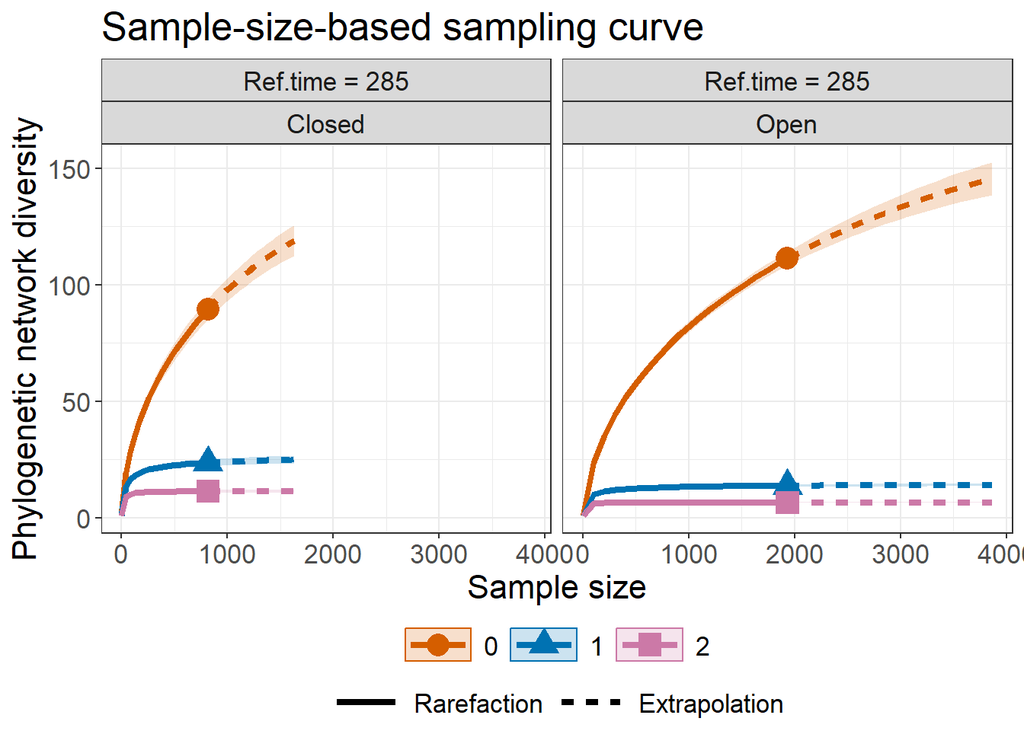

```r
# PD sample-size-based R/E curves, separating by "Assemblage"
ggiNEXT.link(output_qiPD, type = 1, facet.var = "Assemblage")
```

When `facet.var = "Order.q"` is specified in the `ggiNEXT.link` function, it creates a separate plot for each diversity order; within each plot, different color curves represent different assemblages. An example is shown below:

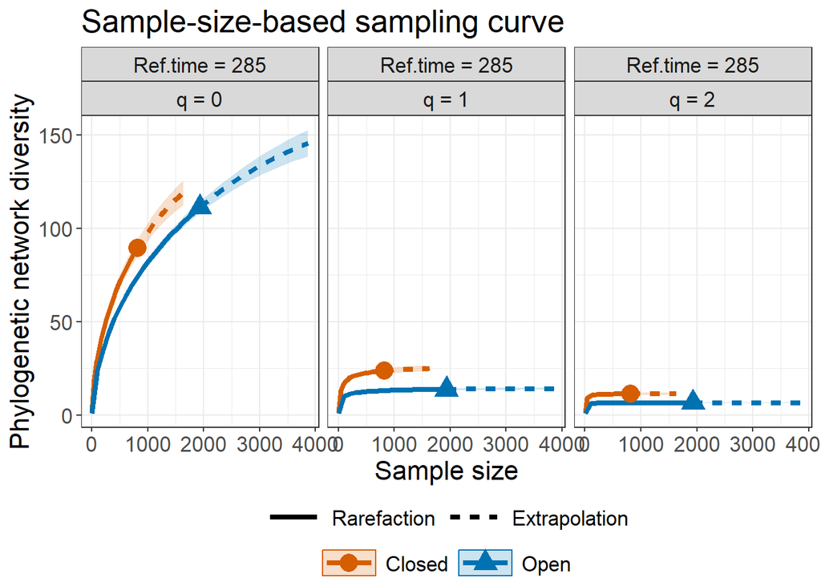

```r
# PD sample-size-based R/E curves, separating by "Order.q"
ggiNEXT.link(output_qiPD, type = 1, facet.var = "Order.q")
```

The following commands return the sample completeness (sample coverage) curve (`type = 2`) in which different colors represent different assemblages.

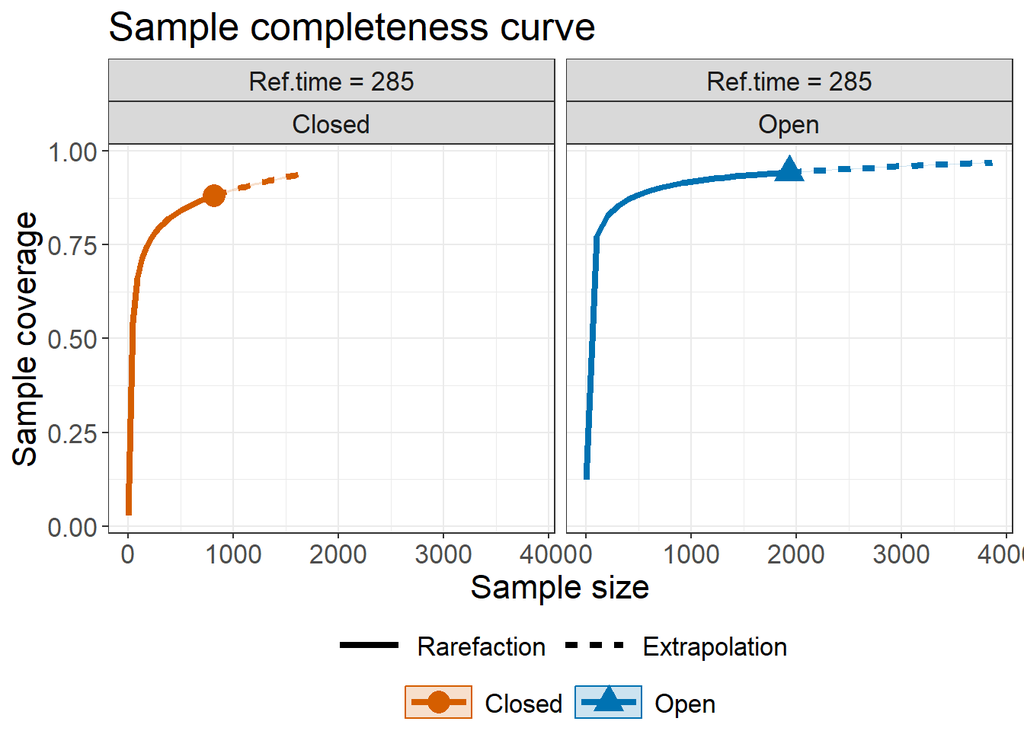

```r
# Sample completeness curves for abundance data, separating by "Assemblage"
ggiNEXT.link(output_qiPD, type = 2, facet.var = "Assemblage")
```

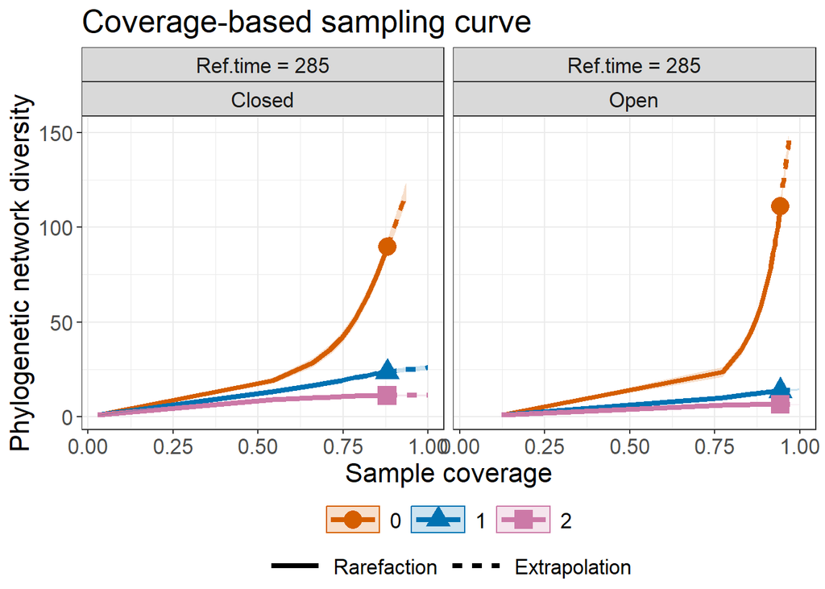

```r
# PD coverage-based R/E curves, separating by "Assemblage"
ggiNEXT.link(output_qiPD, type = 3, facet.var = "Assemblage")
```

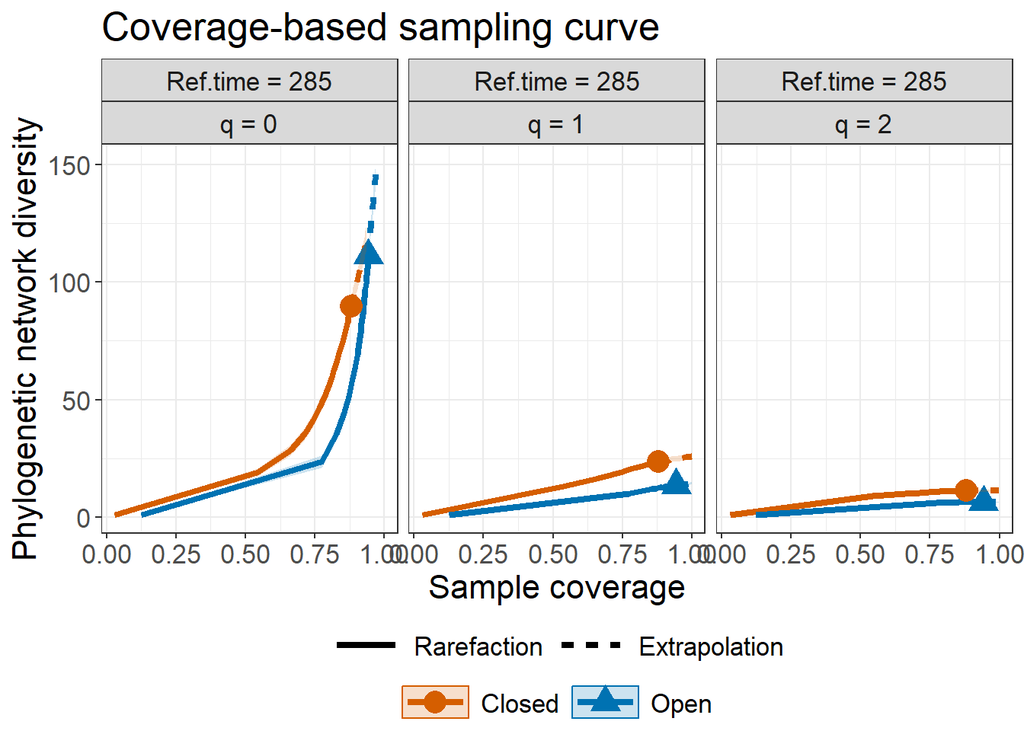

```r
# PD coverage-based R/E curves, separating by "Order.q"
ggiNEXT.link(output_qiPD, type = 3, facet.var = "Order.q")
```

### EXAMPLE 3: qiFD rarefaction/extrapolation for interaction frequency data

Based on the dataset (`beetles_plotA`) included in the package, the following commands return all numerical results for `FD`. The first list of the output (`$FDInfo`) returns basic data information including the name of the Assemblage (`Dataset`), number of observed interaction events in the reference sample (`n`), number of observed species in row assemblage (`S.obs(row)`), number of observed species in column assemblage (`S.obs(col)`), number of observed interactions in the reference sample (`Link.obs`), the proportion of links between species that are realized in the network matrix (`Connectance`), the number of singletons and doubletons in the data (`f1, f2`), the number of singletons and doubletons in the functional group (`a1', a2'`) and the mean weighted pairwise distance between any two interactions (`d_mean`). The output is identical to that based on the function `DataInfo.link()` by specifying `diversity = 'FD'`; see later text). Thus, if only data information is required, the simpler function `DataInfo.link()` (see later text) can be used to obtain the same output. More information about the observed diversity (for any order q between 0 and 2) can be obtained by function `ObsAsy.link()`, which will be introduced later.

```r
data(beetles_plotA)
data(beetles_col_distM)

data <- beetles_plotA
distM <- beetles_col_distM

output_qiFD  <- iNEXT.link(data, diversity = 'FD', q = c(0, 1, 2), nboot = 10, col.distM = distM, FDtype = 'AUC')
output_qiFD$FDInfo
```

```
#>   Dataset    n S.obs(row) S.obs(col) Links.obs Connectance  f1 f2 a1' a2' d_mean
#> 1  Closed  816          6         83       178       0.357  98 31   0   0   8.93
#> 2    Open 1932          6         88       206       0.390 110 33   0   0   8.02
```

The second list of the output (`$FDiNextEst`) includes size- and coverage-based standardized network diversity estimates and related statistics computed for 40 knots by default (for example in the “Closed” assemblage, corresponding to the target sample size `m` = 1, 43, 86, …, 730, 773, 816, 817, 859, …, 1632), which locates the reference sample size at the mid-point of the selected knots. There are two data frames (`$size_based` and `$coverage_based`).

The first data frame (`$size_based`) includes the name of the Assemblage(`$Dataset`), the network diversity order of q (`Order.q`), the target standardized sample size (`m`), the `Method` (`Rarefaction`, `Observed`, or `Extrapolation`, depending on whether the size `m` is less than, equal to, or greater than the reference sample size), the estimated network diversity of order q for a sample of size m (`qiFD`), the bootstrap lower and upper confidence limits for the network diversity of order q (`qiFD.LCL` and `qiFD.UCL`) conditioning on the sample size, and the estimated sample coverage for a sample of size m (`SC`) along with the bootstrap lower and upper confidence limits for the expected sample coverage (`SC.LCL` and `SC.UCL`). These sample coverage/completeness estimates with confidence intervals are used for plotting the sample completeness curve. If the argument `nboot` is greater than zero, then a bootstrap method is applied to obtain the confidence intervals for the diversity and sample coverage estimates. Otherwise, all confidence intervals will not be computed. Here only the first six rows of the `$size_based` output are displayed:

```r
output_qiFD$FDiNextEst$size_based
```

```
#>   Dataset Order.q   m      Method qiFD qiFD.LCL qiFD.UCL    SC SC.LCL SC.UCL
#> 1  Closed       0   1 Rarefaction  1.0      1.0      1.0 0.029  0.025  0.034
#> 2  Closed       0  43 Rarefaction 13.7     12.5     14.9 0.543  0.504  0.582
#> 3  Closed       0  86 Rarefaction 17.5     15.2     19.8 0.661  0.625  0.697
#> 4  Closed       0 129 Rarefaction 20.0     16.8     23.2 0.713  0.680  0.746
#> 5  Closed       0 172 Rarefaction 21.9     18.0     25.9 0.745  0.715  0.775
#> 6  Closed       0 215 Rarefaction 23.5     18.9     28.2 0.767  0.741  0.794
```

The second data frame (`$coverage_based`) includes the name of assemblage, the network diversity order of q (`Order.q`), the target standardized sample coverage (`SC`), the corresponding sample size for the standardized coverage (`m`), the `Method` (`Rarefaction`, `Observed`, or `Extrapolation`, depending on whether the coverage/completeness `SC` is less than, equal to, or greater than the reference sample coverage/completeness), the estimated network diversity of order q for the target coverage value (`qiFD`), the bootstrap lower and upper confidence limits for the network diversity of order q (`qiFD.LCL` and `qiFD.UCL`) conditioning on the target sample coverage value. Here only the first six rows of the `$coverage_based` output are displayed below: (Note for a fixed coverage value, the confidence interval in the `$coverage_based` table is wider than the corresponding interval in the `$size_based` table. This is because, for a given coverage value, the sample size needed to attain a fixed coverage value varies with bootstrap replication, leading to higher uncertainty on the resulting diversity estimate.)

```r
output_qiFD$FDiNextEst$coverage_based
```

```
#>   Dataset Order.q    SC   m      Method qiFD qiFD.LCL qiFD.UCL
#> 1  Closed       0 0.029   1 Rarefaction  1.0    0.866     1.13
#> 2  Closed       0 0.543  43 Rarefaction 13.7   11.675    15.65
#> 3  Closed       0 0.661  86 Rarefaction 17.5   13.837    21.17
#> 4  Closed       0 0.713 129 Rarefaction 20.0   14.937    25.09
#> 5  Closed       0 0.745 172 Rarefaction 21.9   15.818    28.06
#> 6  Closed       0 0.767 215 Rarefaction 23.5   16.594    30.44
```

The third list of the output (`$FDAsyEst`) includes the name of the Assemblage (`$Dataset`), diversity label (`qiFD`, species richness for q = 0, Shannon diversity for q = 1, and Simpson diversity for q = 2), the observed network diversity (`FD_obs`), asymptotic network diversity estimate (`FD_asy`) and its estimated bootstrap standard error (`s.e.`) as well as the bootstrap lower and upper confidence limits for the asymptotic network diversity estimate of order q (`qiFD.LCL` and `qiFD.UCL`). These statistics are computed only for q = 0, 1 and 2. More detailed information about asymptotic and observed diversity estimates for any order q between 0 and 2 can be obtained from function `ObsAsy.link()`. The output for `$FDAsyEst` is shown below:

```r
output_qiFD$FDAsyEst
```

```
#>   Dataset              qiFD FD_obs FD_asy   s.e. qiFD.LCL qiFD.UCL
#> 1  Closed  Species richness  33.95   43.5 17.872     8.49    78.54
#> 2  Closed Shannon diversity  17.04   18.2  1.041    16.14    20.22
#> 3  Closed Simpson diversity  11.59   11.8  0.651    10.52    13.07
#> 4    Open  Species richness  38.70   51.8 24.633     3.49   100.05
#> 5    Open Shannon diversity  10.67   10.9  0.499     9.96    11.91
#> 6    Open Simpson diversity   6.38    6.4  0.149     6.11     6.69
```

The `ggiNEXT.link` function can be used to make graphical displays for rarefaction and extrapolation sampling curves. When `facet.var = "Assemblage"` is specified in the `ggiNEXT.link` function, it creates a separate plot for each assemblage; within each assemblage, different color curves represent diversity of different orders. An example for showing sample-size-based rarefaction/extrapolation curves (`type = 1`) is given below:

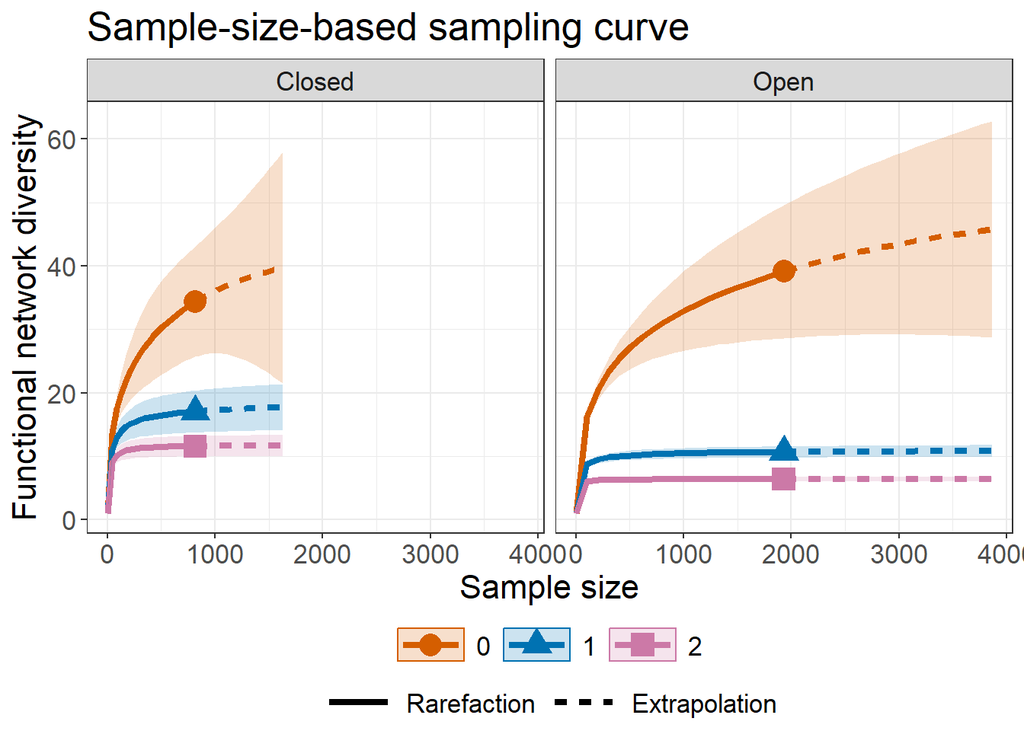

```r
# FD sample-size-based R/E curves, separating by "Assemblage"
ggiNEXT.link(output_qiFD, type = 1, facet.var = "Assemblage")
```

When `facet.var = "Order.q"` is specified in the `ggiNEXT.link` function, it creates a separate plot for each diversity order; within each plot, different color curves represent different assemblages. An example is shown below:

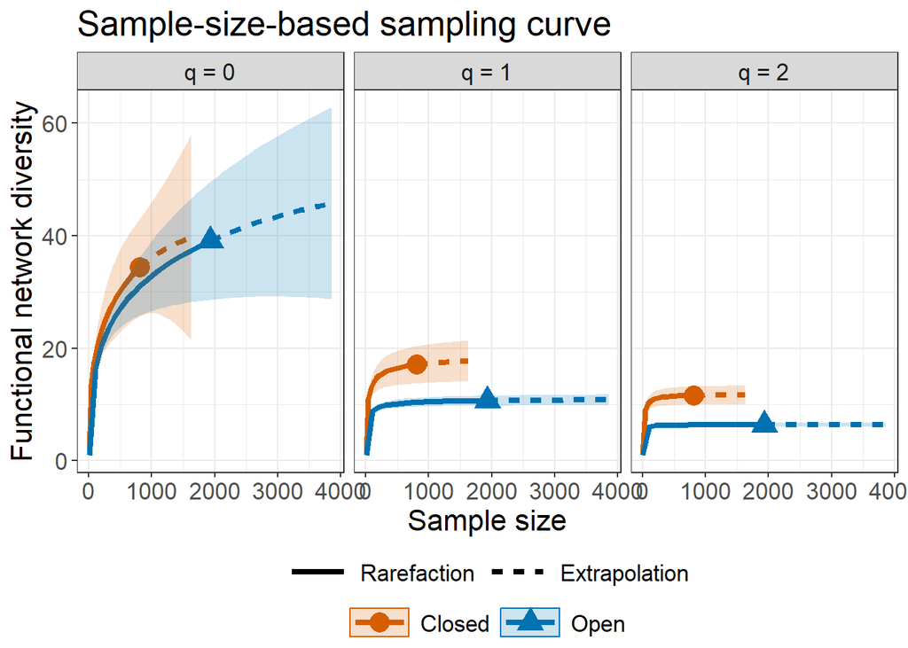

```r
# FD sample-size-based R/E curves, separating by "Order.q"
ggiNEXT.link(output_qiFD, type = 1, facet.var = "Order.q")
```

The following commands return the sample completeness (sample coverage) curve (`type = 2`) in which different colors represent different assemblages.

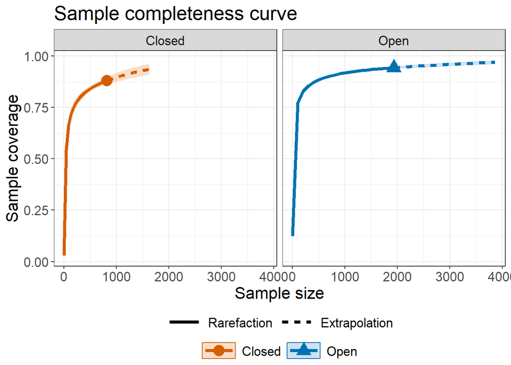

```r
# Sample completeness curves for abundance data, separating by "Assemblage"
ggiNEXT.link(output_qiFD, type = 2, facet.var = "Assemblage")
```

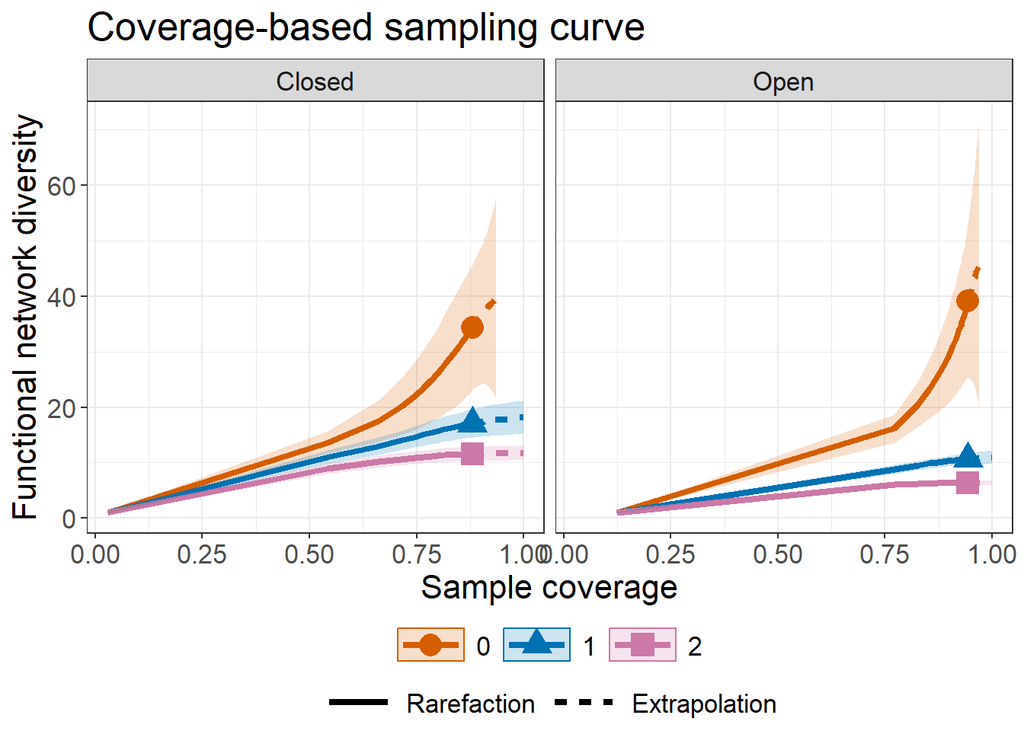

```r
# FD coverage-based R/E curves, separating by "Assemblage"
ggiNEXT.link(output_qiFD, type = 3, facet.var = "Assemblage")
```

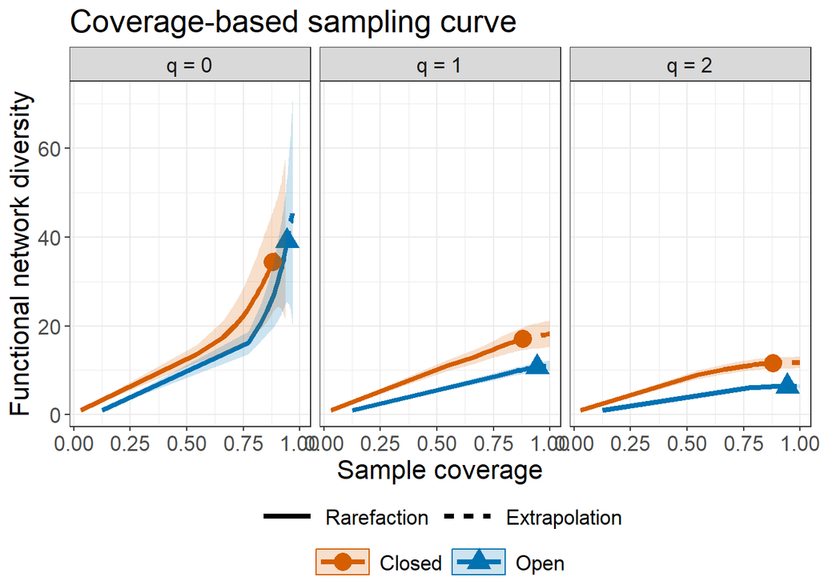

```r
# FD coverage-based R/E curves, separating by "Order.q"
ggiNEXT.link(output_qiFD, type = 3, facet.var = "Order.q")
```

## FUNCTION DataInfo.link(): DATA INFORMATION

The function `DataInfo.link()` provides basic data information for the reference sample in each individual assemblage. The function `DataInfo.link()` with default arguments is shown below:

```r
DataInfo.link(data, diversity = "TD", row.tree = NULL,
              col.tree = NULL, row.distM = NULL, col.distM = NULL)
```

All arguments in the above function are the same as those for the main function `iNEXT.link`. Running the `DataInfo.link()` function returns basic data information including sample size, observed species richness, observed interactions, the proportion of links between species as well as other relevant information in each of the three dimensions of network diversity. We use beetles_plotA to demo the function for each dimension of network diversity.

### TAXONOMIC NETWORK DIVERSITY (qiTD): Basic data information for interaction frequency data

```r
data(beetles_plotA)
DataInfo.link(beetles_plotA, diversity = 'TD')
```

```
#>   Networks    n S.obs(row) S.obs(col) Links.obs Connectance Coverage  f1 f2 f3 f4 f5 f6 f7 f8 f9 f10
#> 1   Closed  816          6         83       178       0.357    0.880  98 31 15  3  3  5  0  2  2   1
#> 2     Open 1932          6         88       206       0.390    0.943 110 33 15  8  7  5  3  2  3   2
```

Output description:

- `Netwrok` = assemblage name.
- `n` = number of observed interaction events in the reference sample (sample size).
- `S.obs(row)` = number of observed species in row assemblage.
- `S.obs(col)` = number of observed species in column assemblage.
- `Link.obs` = number of observed interactions in the reference sample.
- `Connectance` = the proportion of links between species that are realized in the network matrix.
- `Coverage` =estimator of the sample coverage of the reference sample.
- `f1`-`f10` = the first ten frequency counts in the reference sample.

### PHYLOGENETIC NETWORK DIVERSITY (qiPD): Basic data information for interaction frequency data

```r
data(beetles_plotA)
data(beetles_col_tree)
DataInfo.link(data = beetles_plotA, diversity = 'PD', col.tree = beetles_col_tree)
```

```
#>   Networks    n S.obs(row) S.obs(col) Links.obs Connectance f1* f2*    g1   g2 PD.obs T1*T2
#> 1   Closed  816          6         83       178       0.357 171  76 11509 3873    924   285
#> 2     Open 1932          6         88       206       0.390 190  76 13918 5172   1014   285
```

Output description:

- `Netwrok` = assemblage name.
- `n` = number of observed interaction events in the reference sample (sample size).
- `S.obs(row)` = number of observed species in row assemblage.
- `S.obs(col)` = number of observed species in column assemblage.
- `Link.obs` = number of observed interactions in the reference sample.
- `Connectance` = the proportion of links between species that are realized in the network matrix.
- `f1*`,`f2*` = the number of singletons and doubletons in the node/branch set.
- `g1`,`g2` = the total branch length of those singletons/doubletons in the node/branch set.
- `PD.obs` = the observed total branch length in the phylogenetic tree
- `T1*T2` = the product of column tree depth and row tree depth

### FUNCTIONAL NETWORK DIVERSITY (qiFD): Basic data information for interaction frequency data

```r
data(beetles_plotA)
data(beetles_col_distM)
DataInfo.link(data = beetles_plotA, diversity = 'FD', col.distM = beetles_col_distM)
```

```
#>   Networks    n S.obs(row) S.obs(col) Links.obs Connectance  f1 f2 a1' a2' d_mean
#> 1   Closed  816          6         83       178       0.357  98 31   0   0   8.93
#> 2     Open 1932          6         88       206       0.390 110 33   0   0   8.02
```

- `Netwrok` = assemblage name.
- `n` = number of observed interaction events in the reference sample (sample size).
- `S.obs(row)` = number of observed species in row assemblage.
- `S.obs(col)` = number of observed species in column assemblage.
- `Link.obs` = number of observed interactions in the reference sample.
- `Connectance` = the proportion of links between species that are realized in the network matrix.
- `f1`,`f2` = the number of singletons and doubletons in the data .
- `a1'`,`a2'` = the number of singletons and doubletons in the functional group.
- `d_mean` = the mean weighted pairwise distance between any two interactions.

## FUNCTION estimateD.link(): POINT ESTIMATION

`estimateD.link` is used to compute 3D network diversity (qiTD, qiPD, qiFD) estimates with q = 0, 1, 2 under any specified levels of sample size (when `base = "size"`) and sample coverage values (when `base = "coverage"`) for interaction frequency data. When `base = "size"`, `level` can be specified with a particular vector of sample sizes (greater than 0); if `level = NULL`, this function computes the diversity estimates for the minimum sample size among all samples extrapolated to the double reference sizes. When `base = "coverage"`, `level` can be specified with a particular vector of sample coverage values (between 0 and 1); if `level = NULL`, this function computes the diversity estimates for the minimum sample coverage among all samples extrapolated to the double reference sizes. All arguments in the function are the same as those for the main function `iNEXT.link`.

```r
estimateD.link(data, diversity = "TD", q = c(0, 1, 2),
               base = "coverage", level = NULL, nboot = 50, conf = 0.95,
               PDtype = "meanPD", row.tree = NULL, col.tree = NULL, row.distM = NULL,
               col.distM = NULL, FDtype = "AUC", FDtau = NULL)
```

## TAXONOMIC NETWORK DIVERSITY (TD): point estimation

### Example 4: qiTD for interaction frequency data with two target coverage/completeness values (93% and 97%)

The following commands return the qiTD estimates with two specified levels of sample coverage/completeness (93% and 97%) based on the `beetles_plotA`.

```r
data(beetles_plotA)
output_est_qiTD <- estimateD.link(beetles_plotA, diversity = 'TD', q = c(0,1,2),
                                  base = "coverage", level = c(0.93, 0.97))
output_est_qiTD
```

```
#>    Assemblage Order.q   SC    m        Method   qiTD   s.e. qiTD.LCL qiTD.UCL
#> 1      Closed       0 0.93 1511 Extrapolation 242.47 22.256   198.85   286.09
#> 2      Closed       0 0.97 2603 Extrapolation 294.04 29.559   236.10   351.97
#> 3      Closed       1 0.93 1511 Extrapolation  71.88  4.039    63.97    79.80
#> 4      Closed       1 0.97 2603 Extrapolation  77.12  4.289    68.71    85.52
#> 5      Closed       2 0.93 1511 Extrapolation  33.22  1.740    29.81    36.63
#> 6      Closed       2 0.97 2603 Extrapolation  33.52  1.766    30.06    36.98
#> 7        Open       0 0.93 1349   Rarefaction 169.29 13.066   143.69   194.90
#> 8        Open       0 0.97 3993 Extrapolation 292.66 24.193   245.24   340.08
#> 9        Open       1 0.93 1349   Rarefaction  22.55  1.058    20.48    24.62
#> 10       Open       1 0.97 3993 Extrapolation  24.75  1.094    22.61    26.90
#> 11       Open       2 0.93 1349   Rarefaction   8.05  0.263     7.53     8.56
#> 12       Open       2 0.97 3993 Extrapolation   8.07  0.264     7.56     8.59
```

### Example 5: qiPD for interaction frequency data with two target coverage/completeness values (97.5% and 99%)

The following commands return the qiPD estimates with two specified levels of sample coverage/completeness (97.5% and 99%) based on the `beetles_plotA`.

```r
data(beetles_plotA)
data(beetles_col_tree)
output_est_qiPD <- estimateD.link(beetles_plotA, diversity = 'PD', q = c(0,1,2),
                                  base = "coverage", level = c(0.975, 0.99), col.tree = beetles_col_tree)
output_est_qiPD
```

```
#>    Assemblage Order.q    SC    m        Method   qiPD  s.e. qiPD.LCL qiPD.UCL Reftime   Type
#> 1      Closed       0 0.975 2838 Extrapolation 138.21 3.659   131.03   145.38     285 meanPD
#> 2      Closed       1 0.975 2838 Extrapolation  25.57 0.590    24.41    26.72     285 meanPD
#> 3      Closed       2 0.975 2838 Extrapolation  11.35 0.291    10.78    11.92     285 meanPD
#> 4      Closed       0 0.990 4018 Extrapolation 145.23 4.282   136.84   153.62     285 meanPD
#> 5      Closed       1 0.990 4018 Extrapolation  25.76 0.600    24.58    26.93     285 meanPD
#> 6      Closed       2 0.990 4018 Extrapolation  11.36 0.293    10.79    11.93     285 meanPD
#> 7        Open       0 0.975 4580 Extrapolation 153.21 3.686   145.99   160.44     285 meanPD
#> 8        Open       1 0.975 4580 Extrapolation  14.15 0.274    13.62    14.69     285 meanPD
#> 9        Open       2 0.975 4580 Extrapolation   6.51 0.074     6.37     6.66     285 meanPD
#> 10       Open       0 0.990 7530 Extrapolation 169.30 5.059   159.38   179.21     285 meanPD
#> 11       Open       1 0.990 7530 Extrapolation  14.31 0.280    13.76    14.86     285 meanPD
#> 12       Open       2 0.990 7530 Extrapolation   6.51 0.074     6.37     6.66     285 meanPD
```

### Example 6: qiFD for interaction frequency data with with two target sample sizes (500 and 1000)

```r
data(beetles_plotA)
data(beetles_col_distM)
output_est_qiFD <- estimateD.link(beetles_plotA, diversity = 'FD', q = c(0,1,2), nboot = 10,
                                  base = "size", level = c(500, 1000), col.distM = beetles_col_distM, FDtype = "AUC")
output_est_qiFD
```

```
#>   Assemblage Order.q    m      Method    SC  qiFD  s.e. qiFD.LCL qiFD.UCL
#> 1     Closed       0  500 Rarefaction 0.841 30.18 2.948    24.40    35.96
#> 2     Closed       1  500 Rarefaction 0.841 16.49 1.001    14.53    18.45
#> 3     Closed       2  500 Rarefaction 0.841 11.47 0.538    10.42    12.53
#> 4       Open       0 1000 Rarefaction 0.918 32.88 2.812    27.36    38.39
#> 5       Open       1 1000 Rarefaction 0.918 10.48 0.404     9.69    11.28
#> 6       Open       2 1000 Rarefaction 0.918  6.37 0.186     6.00     6.73
```

## FUNCTION ObsAsy.link: ASYMPTOTIC AND OBSERVED NETWORK DIVERSITY PROFILES

```r
ObsAsy.link(data, diversity = "TD", q = seq(0, 2, 0.2),  nboot = 30,
            conf = 0.95, method = c("Asymptotic", "Observed"),
            row.tree = NULL, col.tree = NULL, PDtype = "meanPD", row.distM = NULL,
            col.distM = NULL, FDtype = "AUC", FDtau = NULL)
```

All arguments in the above function are the same as those for the main function `iNEXT.link` (except that the default of `q` here is `seq(0, 2, 0.2)`). The function `ObsAsy.link()` computes observed and asymptotic network diversity of order q between 0 and 2 (in increments of 0.2) for 3D network diversity; these 3D values with different order q can be used to depict a q-profile in the `ggObsAsy.link` function.

For each dimension, by default, both the observed and asymptotic diversity estimates will be computed.

## FUNCTION ggObsAsy.link(): GRAPHIC DISPLAYS OF DIVERSITY PROFILES

```r
ggObsAsy.link(output)
```

`ggObsAsy.link` is a ggplot2 extension for an `ObsAsy.link` object to plot 3D q-profile (which depicts the observed network diversity and asymptotic network diversity estimate with respect to order q) for q between 0 and 2 (in increments of 0.2).

In the plot of profiles, only confidence intervals of the asymptotic network diversity will be shown when both the observed and asymptotic network diversity estimates are computed.

## TAXONOMIC NETWORK DIVERSITY (qiTD): q-profiles

### Example 7: qiTD q-profiles for interaction frequency data

The following commands returns the observed and asymptotic taxonomic network diversity (‘qiTD’) for the `beetles_plotA`, along with its confidence interval for diversity order q between 0 to 2. Here only the first ten rows of the output are shown.

```r
data(beetles_plotA)
output_ObsAsy_qiTD <- ObsAsy.link(data = beetles_plotA, diversity = 'TD', q = seq(0, 2, 0.2))
output_ObsAsy_qiTD
```

```
#>    Network Order.q  qiTD  s.e. qiTD.LCL qiTD.UCL     Method
#> 1   Closed     0.0 332.7 27.23    283.2    384.4 Asymptotic
#> 2   Closed     0.2 266.0 19.26    233.0    301.0 Asymptotic
#> 3   Closed     0.4 203.2 13.11    179.8    224.4 Asymptotic
#> 4   Closed     0.6 149.5  9.10    134.9    162.8 Asymptotic
#> 5   Closed     0.8 108.6  6.71     96.8    120.6 Asymptotic
#> 6   Closed     1.0  80.3  5.16     71.5     90.2 Asymptotic
#> 7   Closed     1.2  62.0  4.04     54.9     70.3 Asymptotic
#> 8   Closed     1.4  50.3  3.24     44.7     57.0 Asymptotic
#> 9   Closed     1.6  42.7  2.68     38.1     48.1 Asymptotic
#> 10  Closed     1.8  37.6  2.31     33.8     42.1 Asymptotic
```

The following commands plot the corresponding q-profile, along with its confidence interval for q between 0 to 2.

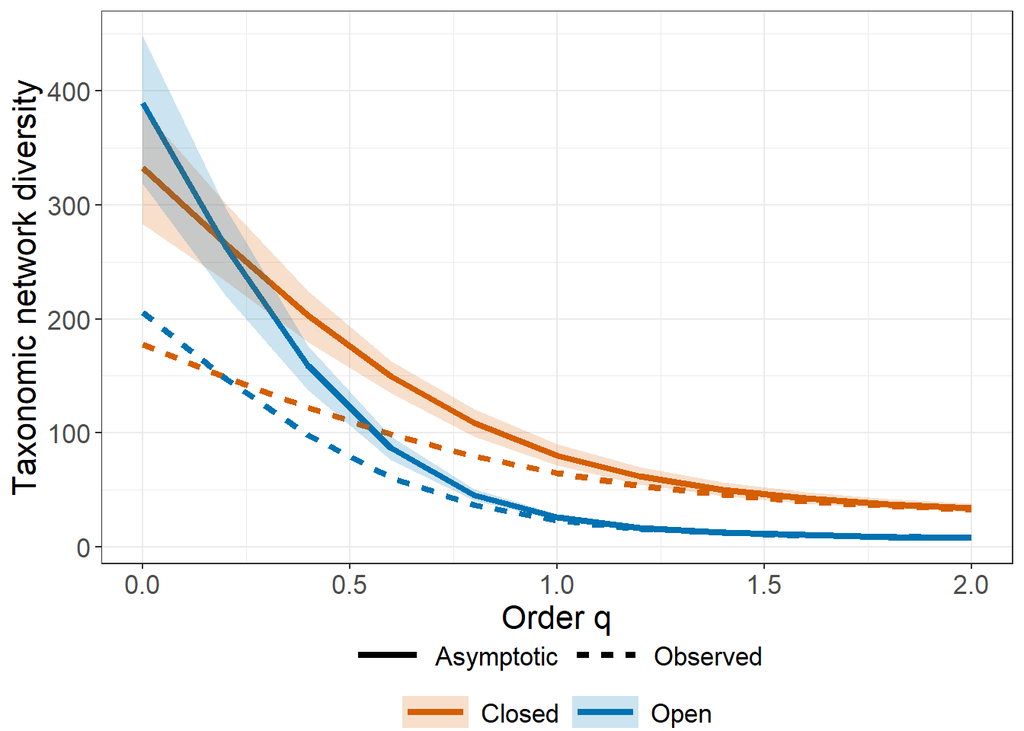

```r
# q-profile curves
ggObsAsy.link(output_ObsAsy_qiTD)
```

## PHYLOGENETIC NETWORK DIVERSITY (qiPD): q-profiles

### Example 8: qiPD q-profiles for interaction frequency data

The following commands returns the observed and asymptotic phylogenetic network diversity (‘qiPD’) for the `beetles_plotA`, along with its confidence interval for network diversity order q between 0 to 2. Here only the first ten rows of the output are shown.

```r
data(beetles_plotA)
data(beetles_col_tree)
output_ObsAsy_qiPD <- ObsAsy.link(data = beetles_plotA, diversity = 'PD', q = seq(0, 2, 0.2), col.tree = beetles_col_tree)
output_ObsAsy_qiPD
```

```
#>    Network Order.q  qiPD  s.e. qiPD.LCL qiPD.UCL     Method Reftime   Type
#> 1   Closed     0.0 149.5 6.239    137.3    161.7 Asymptotic     285 meanPD
#> 2   Closed     0.2 100.1 3.475     93.3    106.9 Asymptotic     285 meanPD
#> 3   Closed     0.4  71.1 2.417     66.3     75.8 Asymptotic     285 meanPD
#> 4   Closed     0.6  49.4 1.785     46.0     52.9 Asymptotic     285 meanPD
#> 5   Closed     0.8  34.9 1.399     32.2     37.7 Asymptotic     285 meanPD
#> 6   Closed     1.0  25.8 1.135     23.6     28.1 Asymptotic     285 meanPD
#> 7   Closed     1.2  20.2 0.943     18.4     22.1 Asymptotic     285 meanPD
#> 8   Closed     1.4  16.6 0.801     15.1     18.2 Asymptotic     285 meanPD
#> 9   Closed     1.6  14.3 0.697     12.9     15.6 Asymptotic     285 meanPD
#> 10  Closed     1.8  12.6 0.618     11.4     13.8 Asymptotic     285 meanPD
```

The following commands plot the corresponding q-profile, along with its confidence interval for q between 0 to 2.

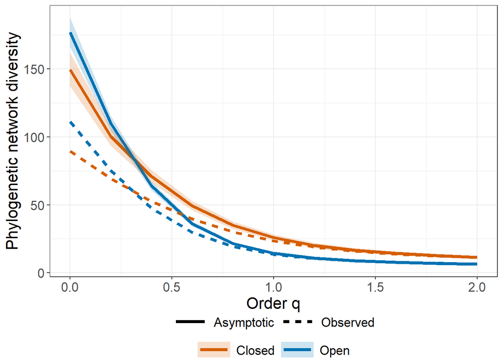

```r
# q-profile curves
ggObsAsy.link(output_ObsAsy_qiPD)
```

## Functional NETWORK DIVERSITY (qiFD): q-profiles

### Example 9: qiFD q-profiles for interaction frequency data

The following commands returns the observed and asymptotic functional network diversity (‘qiFD’) for the `beetles_plotA`, along with its confidence interval for network diversity order q between 0 to 2. Here only the first ten rows of the output are shown.

```r
data(beetles_plotA)
data(beetles_col_distM)
output_ObsAsy_qiFD <- ObsAsy.link(data = beetles, diversity = 'FD', q = seq(0, 2, 0.25),
                                  col.distM = beetles_col_distM, FDtype = "AUC", nboot = 10)
output_ObsAsy_qiFD
```

```
#>    Assemblage Order.q qiFD   s.e. qiFD.LCL qiFD.UCL     Method
#> 1      Closed    0.00 43.8 29.753     0.00    102.1 Asymptotic
#> 2      Closed    0.25 34.3 14.356     6.13     62.4 Asymptotic
#> 3      Closed    0.50 27.5  6.442    14.84     40.1 Asymptotic
#> 4      Closed    0.75 22.0  3.318    15.53     28.5 Asymptotic
#> 5      Closed    1.00 18.1  1.936    14.35     21.9 Asymptotic
#> 6      Closed    1.25 15.5  1.270    13.06     18.0 Asymptotic
#> 7      Closed    1.50 13.8  0.935    11.99     15.7 Asymptotic
#> 8      Closed    1.75 12.6  0.752    11.16     14.1 Asymptotic
#> 9      Closed    2.00 11.8  0.644    10.52     13.0 Asymptotic
#> 10       Open    0.00 52.0 18.274    16.21     87.8 Asymptotic
```

The following commands plot the corresponding q-profile, along with its confidence interval for q between 0 to 2.

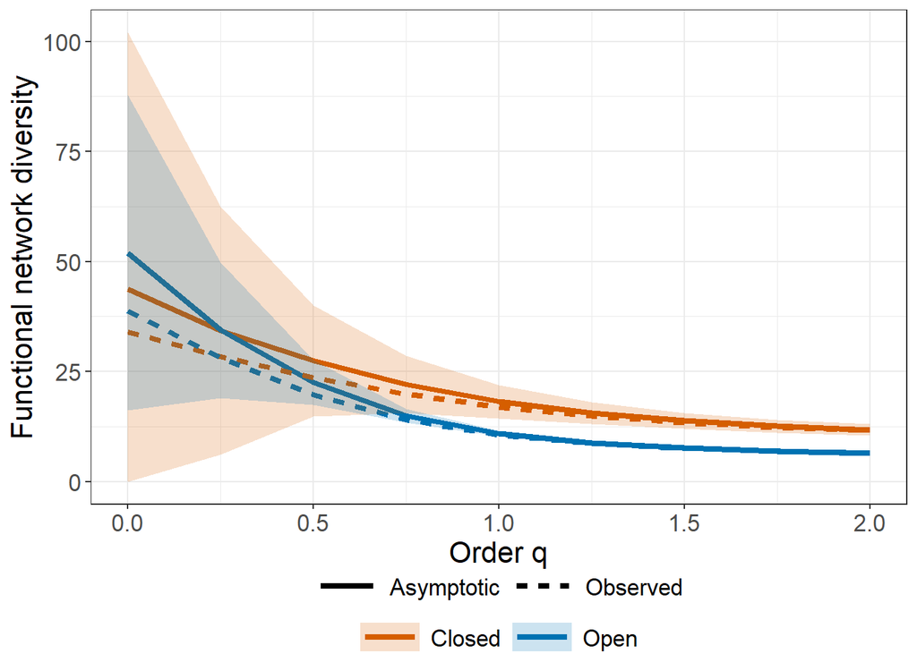

```r
# q-profile curves
ggObsAsy.link(output_ObsAsy_qiFD)
```

## FUNCTION Completeness.link: NETWORK COMPLETENESS PROFILES

Function `Completeness.link()` provides a easy way to compute estimated sample completeness with order q. The arguments is below:

```r
Completeness.link(data, q = seq(0, 2, 0.2), nboot = 30, conf = 0.95)
```

| Argument | Description |
| --- | --- |
| `data` | a `list` of `data.frames`, each `data.frames` represents col.species-by-row.species abundance matrix. |
| `q` | a numerical vector specifying the diversity orders. Default is seq(0, 2, 0.2). |
| `nboot` | a positive integer specifying the number of bootstrap replications when assessing sampling uncertainty and constructing confidence intervals. Bootstrap replications are generally time consuming. Enter… |
| `conf` | a positive number < 1 specifying the level of confidence interval. Default is `0.95`. |

## FUNCTION ggCompleteness.link(): GRAPHIC DISPLAYS OF COMPLETENESS PROFILES

We also provides a realized function `ggCompleteness.link` to plot the output from `Completeness.link()`:

```r
ggCompleteness.link(output)
```

| Argument | Description |
| --- | --- |
| `output` | a table generated from function `Completeness.link`. |

Use data beetles to calculate sample completeness and plot it.

### Example 10: Completeness for interaction frequency data

The following commands returns estimate sample completeness for `beetles_plotA`, along with its confidence interval at network diversity order q from 0 to 2.

```r
data(beetles_plotA)
output_com <- Completeness.link(data = beetles_plotA)
output_com
```

```
#>    Order.q Estimate.SC  s.e. SC.LCL SC.UCL Dataset
#> 1      0.0       0.535 0.080  0.378  0.692  Closed
#> 2      0.2       0.576 0.070  0.438  0.714  Closed
#> 3      0.4       0.636 0.056  0.527  0.746  Closed
#> 4      0.6       0.716 0.038  0.642  0.790  Closed
#> 5      0.8       0.803 0.021  0.762  0.844  Closed
#> 6      1.0       0.880 0.010  0.860  0.900  Closed
#> 7      1.2       0.935 0.005  0.925  0.944  Closed
#> 8      1.4       0.967 0.003  0.961  0.973  Closed
#> 9      1.6       0.984 0.002  0.980  0.988  Closed
#> 10     1.8       0.993 0.001  0.990  0.995  Closed
#> 11     2.0       0.997 0.001  0.995  0.998  Closed
#> 12     0.0       0.529 0.058  0.415  0.643    Open
#> 13     0.2       0.578 0.051  0.478  0.679    Open
#> 14     0.4       0.654 0.040  0.575  0.733    Open
#> 15     0.6       0.758 0.025  0.708  0.808    Open
#> 16     0.8       0.867 0.012  0.844  0.889    Open
#> 17     1.0       0.943 0.004  0.936  0.950    Open
#> 18     1.2       0.980 0.001  0.978  0.982    Open
#> 19     1.4       0.994 0.000  0.993  0.995    Open
#> 20     1.6       0.998 0.000  0.998  0.998    Open
#> 21     1.8       0.999 0.000  0.999  1.000    Open
#> 22     2.0       1.000 0.000  1.000  1.000    Open
```

The following commands plot the corresponding q-profile, along with its confidence interval for q between 0 to 2.

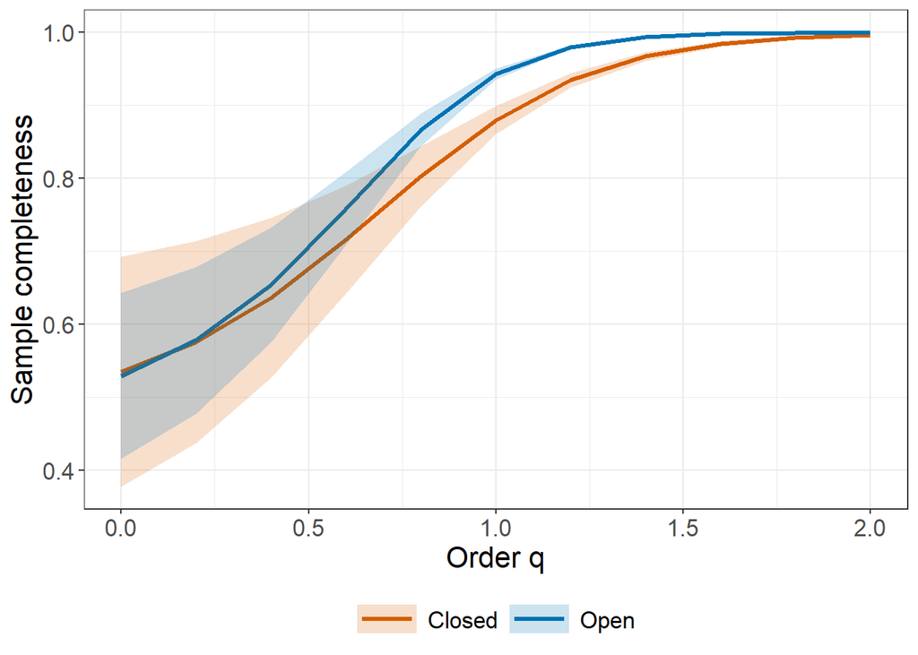

```r
# q-profile curves
ggCompleteness.link(output_com)
```

## FUNCTION Spec.link and ggSpec.link: NETWORK SPECIALIZATION PROFILES

`Spec.link()` the network specialization q-profiles for q between 0 and 2 in increments of 0.2 (by default) based on five classes of specialization measures, and function `ggSpec.link` is used to plot the corresponding specialization profiles. These two functions are specifically for users who only require specialization estimates and profiles. The two functions with arguments are described below:

```r
Spec.link(data, q = seq(0, 2, 0.2), method = "Estimated",
         nboot = 30, conf = 0.95, E.class = c(1:5), SC = NULL)
```

```r
ggSpec.link(output)
```

| Argument | Description |
| --- | --- |
| `data` | a `list` of `data.frames`, each `data.frames` represents col.species-by-row.species abundance matrix. |
| `q` | a numerical vector specifying the diversity orders. Default is (0, 0.2, 0.4,…, 2). |
| `method` | a binary calculation method with ‘Estimated’ or ‘Observed’. |
| `nboot` | a positive integer specifying the number of bootstrap replications when assessing sampling uncertainty and constructing confidence intervals. Bootstrap replications are generally time consuming. Enter… |
| `conf` | a positive number < 1 specifying the level of confidence interval. Default is `0.95`. |
| `E.class` | an integer vector between 1 to 5. There are five transformation for evenness in Chao and Ricotta (2019). Default is 1:5. |
| `C` | a standardized coverage for calculating evenness index. It is used when `method = 'Estimated'`. If `NULL`, then this function computes the diversity estimates for the minimum sample coverage among all… |

A simple example for demonstrating functions `Spec.link` and `ggSpec.link` are given below.

### Example 11: Specialization for interaction frequency data

The dataset `beetles_plotA` is used to estimate specialization at the default standardized sample coverage (`SC = NULL`). Specialization estimates of order q = 0 to q = 2 in increments of 0.2 (by default) will be computed based on five classes of specialization measures. (For q = 0, species abundances are disregarded, so it is not meaningful to evaluate specialization among abundances specifically for q = 0. As q tends to 0, all specialization values tend to 0 as a limiting value.) Function `ggSpec.link` is used to plot the corresponding specialization profiles. Here only the specialization estimates are shown for the first class of evenness measures. The corresponding numerical tables for the other four classes of evenness measures are omitted. Users also can use argument `E.class` to specify which class (e.g., `E.class= 3`) or classes are required.

```r
data(beetles_plotA)
output_spec <- Spec.link(data = beetles_plotA)
output_spec[[1]]
```

```
#>    Order.q Specialization  s.e. Spec.LCL Spec.UCL    SC Dataset Measure
#> 1      0.0          0.000 0.000    0.000    0.000 0.936  Closed  1 - E1
#> 2      0.2          0.156 0.012    0.134    0.179 0.936  Closed  1 - E1
#> 3      0.4          0.246 0.018    0.211    0.280 0.936  Closed  1 - E1
#> 4      0.6          0.279 0.020    0.240    0.318 0.936  Closed  1 - E1
#> 5      0.8          0.267 0.019    0.230    0.304 0.936  Closed  1 - E1
#> 6      1.0          0.224 0.015    0.194    0.254 0.936  Closed  1 - E1
#> 7      1.2          0.168 0.011    0.146    0.190 0.936  Closed  1 - E1
#> 8      1.4          0.115 0.008    0.100    0.130 0.936  Closed  1 - E1
#> 9      1.6          0.073 0.005    0.063    0.083 0.936  Closed  1 - E1
#> 10     1.8          0.044 0.003    0.038    0.051 0.936  Closed  1 - E1
#> 11     2.0          0.026 0.002    0.022    0.031 0.936  Closed  1 - E1
#> 12     0.0          0.000 0.000    0.000    0.000 0.936    Open  1 - E1
#> 13     0.2          0.228 0.007    0.214    0.242 0.936    Open  1 - E1
#> 14     0.4          0.362 0.010    0.342    0.383 0.936    Open  1 - E1
#> 15     0.6          0.426 0.012    0.403    0.449 0.936    Open  1 - E1
#> 16     0.8          0.434 0.012    0.411    0.456 0.936    Open  1 - E1
#> 17     1.0          0.400 0.011    0.380    0.421 0.936    Open  1 - E1
#> 18     1.2          0.343 0.009    0.324    0.361 0.936    Open  1 - E1
#> 19     1.4          0.276 0.008    0.261    0.292 0.936    Open  1 - E1
#> 20     1.6          0.214 0.007    0.200    0.227 0.936    Open  1 - E1
#> 21     1.8          0.161 0.006    0.149    0.173 0.936    Open  1 - E1
#> 22     2.0          0.119 0.005    0.110    0.129 0.936    Open  1 - E1
```

## FUNCTION iNEXTbeta.link

```r
iNEXTbeta.link(data, diversity = "TD", level = seq(0.5, 1, 0.05),
               q = c(0, 1, 2), nboot = 20, conf = 0.95,
               PDtype = "meanPD", row.tree = NULL, col.tree = NULL, row.distM = NULL,
               col.distM = NULL, FDtype = "AUC", FDtau = NULL, FDcut_number = 30)
```

The arguments of this function are briefly described below, and will be explained in more details by illustrative examples in later text. This main function computes gamma, alpha and beta network diversity estimates of order q at specified sample coverage and measures of dissimilarity. By default of `base = “coverage”` and `level = NULL`, then this function computes the gamma, alpha, beta network diversity, and four dissimilarity-turnover indices estimates up to one (for q = 1, 2) or up to the coverage of double the reference sample size (for q = 0).

| Argument | Description |
| --- | --- |
| `data` | data can be input as a list} of data.frame, each data.frame represents col.species-by-row.species abundance matrix |
| `diversity` | selection of diversity type: `TD` = Taxonomic diversity, `PD` = Phylogenetic diversity, and `FD` = Functional diversity. |
| `level` | a sequence specifying the particular sample coverages (between 0 and 1). Default is `seq(0.5, 1, 0.05)`. |
| `q` | a numerical vector specifying the diversity orders. Default is `c(0, 1, 2)`. |
| `nboot` | a positive integer specifying the number of bootstrap replications when assessing sampling uncertainty and constructing confidence intervals. Bootstrap replications are generally time consuming. Enter… |
| `conf` | a positive number < 1 specifying the level of confidence interval. Default is `0.95`. |
| `PDtype` | (required only when `diversity = “PD”`), select PD type: `PDtype = “PD”` (effective total branch length) or `PDtype = “meanPD”` (effective number of equally divergent lineages). Default is `“meanPD”`. |
| `row.tree` | (required only when `diversity = “PD”`), a phylogenetic tree of row assemblage in the pooled network row assemblage. |
| `col.tree` | (required only when `diversity = “PD”`), a phylogenetic tree of column assemblage in the pooled network column assemblage. |
| `row.disM` | (required only when `diversity = “FD”`), a species pairwise distance matrix for all species of row assemblage in the pooled network row assemblage. |
| `col.disM` | (required only when `diversity = “PD”`), a species pairwise distance matrix for all species of column assemblage in the pooled network column assemblage. |
| `FDtype` | (required only when `diversity = “FD”`), select FD type: `FDtype = “tau_value”` for FD under a specified threshold value, or `FDtype = “AUC”` (area under the curve of tau-profile) for an overall FD wh… |
| `FDtau` | (required only when `diversity = “FD”` and FDtype = “tau_value” ), a numerical value between 0 and 1 specifying the tau value (threshold level). If `NULL` (default), then threshold is set to be the me… |

This function returns an `"iNEXTbeta.link"` object which can be further used to make plots using the function `ggiNEXTbeta.link()` to be described below.

### Output of the main function iNEXTbeta.link()

The `iNEXTbeta.link()` function for each of the three dimensions (qiTD, qiPD, and qiFD) returns the `"iNEXTbeta.link"` object including seven data frames for each dataset:

- gamma (standardized gamma network diversity)
- alpha (standardized alpha network diversity)
- beta (standardized beta network diversity)
- 1-C (standardized Sorensen-type non-overlap index)
- 1-U (standardized Jaccard-type non-overlap index)
- 1-V (standardized Sorensen-type turnover index)
- 1-S (standardized Jaccard-type turnover index)

## GRAPHIC DISPLAYS: FUNCTION ggiNEXTbeta.link()

The function `ggiNEXTbeta.link()` with default arguments is described as follows:

```r
ggiNEXTbeta.link(output, type = c("B", "D"))
```

| Argument | Description |
| --- | --- |
| `output` | the output of `iNEXTbeta.link`. |
| `type` | selection of plot type : type = ‘B’ for plotting the gamma, alpha, and beta diversity; type = ‘D’ for plotting 4 turnover dissimilarities. |

The `ggiNEXTbeta.link()` function is a wrapper around the `ggplot2` package to create a R/E curve using a single line of code. The resulting object is of class `"ggplot"`, so it can be manipulated using the `ggplot2` tools. Users can visualize the displays of coverage-based R/E sampling curves of gamma, alpha and beta network diversity as well as four classes of dissimilarity indices by setting the parameter `type`.

## TAXONOMIC NETWORK DIVERSITY (qiTD): RAREFACTION/EXTRAPOLATION VIA EXAMPLES

### Example 12: Alpha, Beta, Gamma network diversity and dissimilarity for interaction frequency data

```r
# Taxonomic diversity
data(beetles_plotA)
output_beta_qiTD = iNEXTbeta.link(data = beetles_plotA, diversity = 'TD', level = NULL, q = c(0, 1, 2))
output_beta_qiTD
```

The output contains seven data frames: `gamma`, `alpha`, `beta`, `1-C`, `1-U`, `1-V`, `1-S`. For each data frame, it includes the name of dataset (`Dataset`), the network diversity order of q (`Order.q`), the standardized sample completeness (`SC`), the corresponding sample size for the standardized coverage value (`Size`), the estimated network diversity of order q for the target coverage value (`Alpha/Beta/Gamma/Dissimilarity`), `Method` (Rarefaction, Observed, or Extrapolation, depending on whether the target coverage is less than, equal to, or greater than the coverage of the reference sample), standard error of the network diversity estimate (`s.e.`), the bootstrap lower and upper confidence limits for the network diversity/dissimilarity of order q with a default significance level of 0.95 (`LCL`, `UCL`). These estimates with confidence intervals in the output are then used for plotting rarefaction and extrapolation curves.

Our network diversity/dissimilarity estimates and related statistics in the default output are displayed for the standardized coverage/completeness value from 0.5 to 1.0 (for q = 1 and 2), in increments of 0.025. In addition, the results for the following four coverage value are also added: `SC(n, alpha)`, `SC(2n, alpha)`, `SC(n, gamma)` and `SC(2n, gamma)` if these values are in the above-specified range. Here `SC(n, alpha)` and `SC(2n, alpha)` represent, respectively, the coverage estimate for the alpha reference sample size n and the extrapolated sample with size 2n in the joint assemblage. Similar definitions pertain to `SC(n, gamma)` and `SC(2n, gamma)` for the gamma reference sample. For beta network diversity and network dissimilarity, the observed sample coverage and extrapolation limit are defined the same as the alpha diversity.

Because all the network diversity/dissimilarity estimates are computed for the standardized coverage range values starting from 0.5, the default setting with `level = NULL` does not work if the observed sample coverage in the alpha/gamma reference sample is less than 50%. In this case, readers should specify sample coverage values using the argument `level`, instead of using `level = NULL`. The suggested maximum coverage value that readers can specify is `SC(2n, alpha)`. Beyond the limit, beta diversity and dissimilarity estimates may be subject to some bias. Below we show the output for taxonomic beta network diversity between the “Closed” and “Open” assemblages.

```
#>             Dataset Order.q    SC   Size Beta                Method  s.e.  LCL  UCL
#> 1  Closed v.s. Open       0 0.500   25.9 1.66           Rarefaction 0.020 1.62 1.70
#> 2  Closed v.s. Open       0 0.525   32.3 1.61           Rarefaction 0.019 1.57 1.64
#> 3  Closed v.s. Open       0 0.550   40.2 1.56           Rarefaction 0.017 1.53 1.60
#> 4  Closed v.s. Open       0 0.575   50.0 1.53           Rarefaction 0.016 1.50 1.57
#> 5  Closed v.s. Open       0 0.600   61.8 1.52           Rarefaction 0.017 1.49 1.55
#> 6  Closed v.s. Open       0 0.625   75.9 1.51           Rarefaction 0.017 1.48 1.55
#> 7  Closed v.s. Open       0 0.650   92.9 1.51           Rarefaction 0.018 1.48 1.55
#> 8  Closed v.s. Open       0 0.675  113.7 1.52           Rarefaction 0.019 1.48 1.56
#> 9  Closed v.s. Open       0 0.700  140.0 1.52           Rarefaction 0.020 1.49 1.56
#> 10 Closed v.s. Open       0 0.725  174.0 1.53           Rarefaction 0.020 1.49 1.57
#> 11 Closed v.s. Open       0 0.750  219.5 1.53           Rarefaction 0.021 1.49 1.58
#> 12 Closed v.s. Open       0 0.775  282.6 1.54           Rarefaction 0.022 1.49 1.58
#> 13 Closed v.s. Open       0 0.800  373.9 1.53           Rarefaction 0.023 1.49 1.58
#> 14 Closed v.s. Open       0 0.825  511.4 1.52           Rarefaction 0.024 1.48 1.57
```

[output cut: 58 more lines]

Run the following code to display the two types of curves:

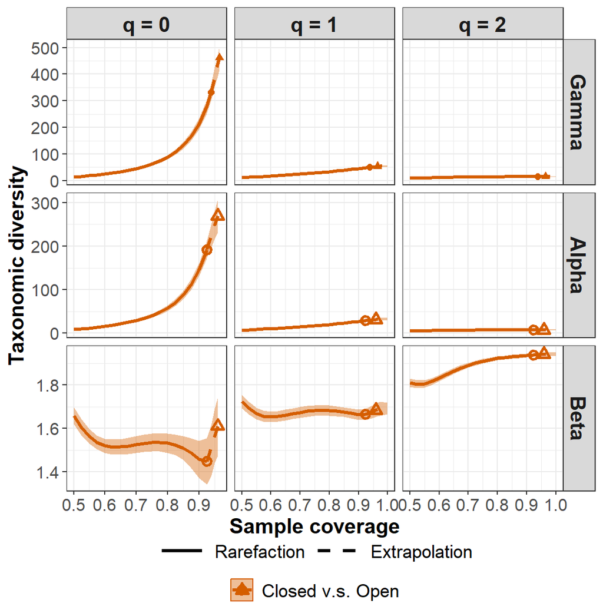

```r
## R/E curves for taxonomic gamma, alpha and beta network diversity
ggiNEXTbeta.link(output_beta_qiTD, type = 'B')
```

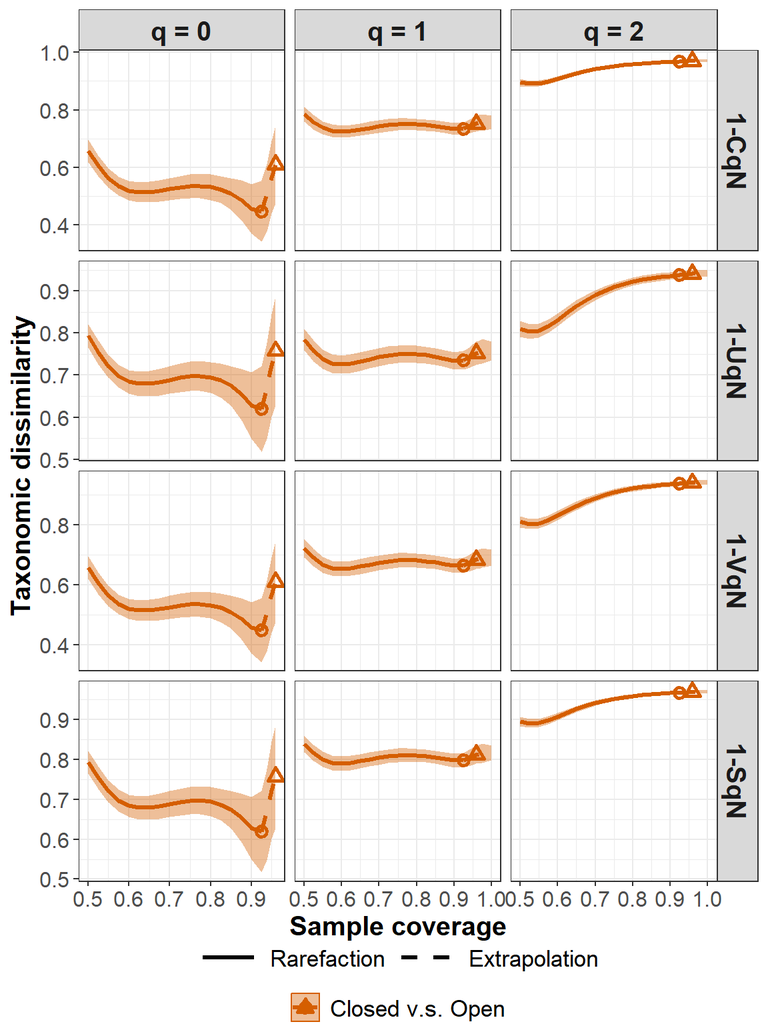

```r
## R/E curves for four taxonomic network dissimilarity indices
ggiNEXTbeta.link(output_beta_qiTD, type = 'D')
```

## PHYLOGENETIC NETWORK DIVERSITY (qiPD): RAREFACTION/EXTRAPOLATION VIA EXAMPLES

### Example 13: Alpha, Beta, Gamma network diversity and dissimilarity for interaction frequency data

```r
# Taxonomic diversity
data(beetles_plotA)
output_beta_qiPD = iNEXTbeta.link(data = beetles_plotA, diversity = 'PD', level = NULL, q = c(0, 1, 2))
output_beta_qiPD
```

The output contains seven data frames: `gamma`, `alpha`, `beta`, `1-C`, `1-U`, `1-V`, `1-S`. For each data frame, it includes the name of dataset (`Dataset`), the network diversity order of q (`Order.q`), the standardized sample completeness (`SC`), the corresponding sample size for the standardized coverage value (`Size`), the estimated network diversity of order q for the target coverage value (`Alpha/Beta/Gamma/Dissimilarity`), `Method` (Rarefaction, Observed, or Extrapolation, depending on whether the target coverage is less than, equal to, or greater than the coverage of the reference sample), standard error of the network diversity estimate (`s.e.`), the bootstrap lower and upper confidence limits for the network diversity/dissimilarity of order q with a default significance level of 0.95 (`LCL`, `UCL`). These estimates with confidence intervals in the output are then used for plotting rarefaction and extrapolation curves.

Our network diversity/dissimilarity estimates and related statistics in the default output are displayed for the standardized coverage/completeness value from 0.5 to 1.0 (for q = 1 and 2), in increments of 0.025. In addition, the results for the following four coverage value are also added: `SC(n, alpha)`, `SC(2n, alpha)`, `SC(n, gamma)` and `SC(2n, gamma)` if these values are in the above-specified range. Here `SC(n, alpha)` and `SC(2n, alpha)` represent, respectively, the coverage estimate for the alpha reference sample size n and the extrapolated sample with size 2n in the joint assemblage. Similar definitions pertain to `SC(n, gamma)` and `SC(2n, gamma)` for the gamma reference sample. For beta network diversity and network dissimilarity, the observed sample coverage and extrapolation limit are defined the same as the alpha diversity.

Because all the network diversity/dissimilarity estimates are computed for the standardized coverage range values starting from 0.5, the default setting with `level = NULL` does not work if the observed sample coverage in the alpha/gamma reference sample is less than 50%. In this case, readers should specify sample coverage values using the argument `level`, instead of using `level = NULL`. The suggested maximum coverage value that readers can specify is `SC(2n, alpha)`. Beyond the limit, beta diversity and dissimilarity estimates may be subject to some bias. Below we show the output for phylogenetic beta network diversity between the “Closed” and “Open” assemblages.

```
#>             Dataset Order.q    SC   Size Beta                Method  s.e.  LCL  UCL
#> 1  Closed v.s. Open       0 0.500   25.9 1.56           Rarefaction 0.023 1.52 1.61
#> 2  Closed v.s. Open       0 0.525   32.3 1.52           Rarefaction 0.022 1.47 1.56
#> 3  Closed v.s. Open       0 0.550   40.2 1.48           Rarefaction 0.019 1.44 1.51
#> 4  Closed v.s. Open       0 0.575   50.0 1.45           Rarefaction 0.016 1.42 1.48
#> 5  Closed v.s. Open       0 0.600   61.8 1.43           Rarefaction 0.013 1.41 1.46
#> 6  Closed v.s. Open       0 0.625   75.9 1.42           Rarefaction 0.012 1.40 1.45
#> 7  Closed v.s. Open       0 0.650   92.9 1.42           Rarefaction 0.013 1.40 1.45
#> 8  Closed v.s. Open       0 0.675  113.7 1.42           Rarefaction 0.014 1.39 1.45
#> 9  Closed v.s. Open       0 0.700  140.0 1.42           Rarefaction 0.015 1.39 1.45
#> 10 Closed v.s. Open       0 0.725  174.0 1.42           Rarefaction 0.016 1.39 1.45
#> 11 Closed v.s. Open       0 0.750  219.5 1.42           Rarefaction 0.017 1.39 1.46
#> 12 Closed v.s. Open       0 0.775  282.6 1.42           Rarefaction 0.019 1.38 1.46
#> 13 Closed v.s. Open       0 0.800  373.9 1.42           Rarefaction 0.022 1.37 1.46
#> 14 Closed v.s. Open       0 0.825  511.4 1.41           Rarefaction 0.025 1.36 1.46
```

[output cut: 58 more lines]

Run the following code to display the two types of curves:

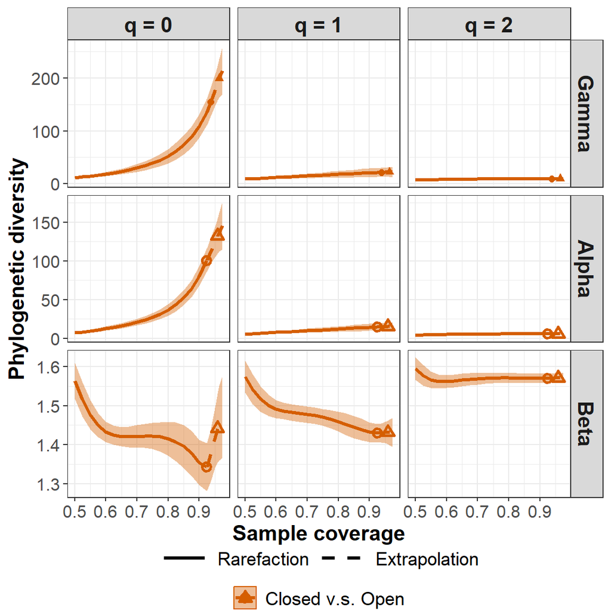

```r
## R/E curves for phylogenetic gamma, alpha and beta network diversity
ggiNEXTbeta.link(output_beta_qiPD, type = 'B')
```

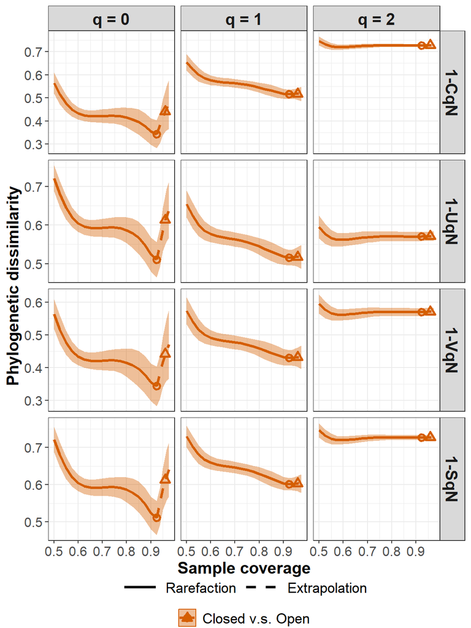

```r
## R/E curves for four phylogenetic network dissimilarity indices
ggiNEXTbeta.link(output_beta_qiPD, type = 'D')
```

## FUNCTIONAL NETWORK DIVERSITY (qiFD): RAREFACTION/EXTRAPOLATION VIA EXAMPLES

### Example 14: Alpha, Beta, Gamma network diversity and dissimilarity for interaction frequency data

```r
# Taxonomic diversity
data(beetles_plotA)
data(beetles_col_distM)
output_beta_qiFD = iNEXTbeta.link(data = beetles, diversity = 'FD', level = NULL, q = c(0, 1, 2),
                                  col.distM = beetles_col_distM, FDtype = "AUC", nboot = 0)
output_beta_qiFD
```

The output contains seven data frames: `gamma`, `alpha`, `beta`, `1-C`, `1-U`, `1-V`, `1-S`. For each data frame, it includes the name of dataset (`Dataset`), the network diversity order of q (`Order.q`), the standardized sample completeness (`SC`), the corresponding sample size for the standardized coverage value (`Size`), the estimated network diversity of order q for the target coverage value (`Alpha/Beta/Gamma/Dissimilarity`), `Method` (Rarefaction, Observed, or Extrapolation, depending on whether the target coverage is less than, equal to, or greater than the coverage of the reference sample), standard error of the network diversity estimate (`s.e.`), the bootstrap lower and upper confidence limits for the network diversity/dissimilarity of order q with a default significance level of 0.95 (`LCL`, `UCL`). These estimates with confidence intervals in the output are then used for plotting rarefaction and extrapolation curves.

Our network diversity/dissimilarity estimates and related statistics in the default output are displayed for the standardized coverage/completeness value from 0.5 to 1.0 (for q = 1 and 2), in increments of 0.025. In addition, the results for the following four coverage value are also added: `SC(n, alpha)`, `SC(2n, alpha)`, `SC(n, gamma)` and `SC(2n, gamma)` if these values are in the above-specified range. Here `SC(n, alpha)` and `SC(2n, alpha)` represent, respectively, the coverage estimate for the alpha reference sample size n and the extrapolated sample with size 2n in the joint assemblage. Similar definitions pertain to `SC(n, gamma)` and `SC(2n, gamma)` for the gamma reference sample. For beta network diversity and network dissimilarity, the observed sample coverage and extrapolation limit are defined the same as the alpha diversity.

```
#>             Dataset Order.q    SC   Size Beta                Method s.e. LCL UCL
#> 1  Closed v.s. Open       0 0.500   25.9 1.41           Rarefaction   NA  NA  NA
#> 2  Closed v.s. Open       0 0.525   32.3 1.35           Rarefaction   NA  NA  NA
#> 3  Closed v.s. Open       0 0.550   40.2 1.31           Rarefaction   NA  NA  NA
#> 4  Closed v.s. Open       0 0.575   50.0 1.27           Rarefaction   NA  NA  NA
#> 5  Closed v.s. Open       0 0.600   61.8 1.24           Rarefaction   NA  NA  NA
#> 6  Closed v.s. Open       0 0.625   75.9 1.22           Rarefaction   NA  NA  NA
#> 7  Closed v.s. Open       0 0.650   92.9 1.20           Rarefaction   NA  NA  NA
#> 8  Closed v.s. Open       0 0.675  113.7 1.18           Rarefaction   NA  NA  NA
#> 9  Closed v.s. Open       0 0.700  140.0 1.16           Rarefaction   NA  NA  NA
#> 10 Closed v.s. Open       0 0.725  174.0 1.15           Rarefaction   NA  NA  NA
#> 11 Closed v.s. Open       0 0.750  219.5 1.13           Rarefaction   NA  NA  NA
#> 12 Closed v.s. Open       0 0.775  282.6 1.12           Rarefaction   NA  NA  NA
#> 13 Closed v.s. Open       0 0.800  373.9 1.10           Rarefaction   NA  NA  NA
#> 14 Closed v.s. Open       0 0.825  511.4 1.09           Rarefaction   NA  NA  NA
```

[output cut: 58 more lines]

Run the following code to display the two types of curves:

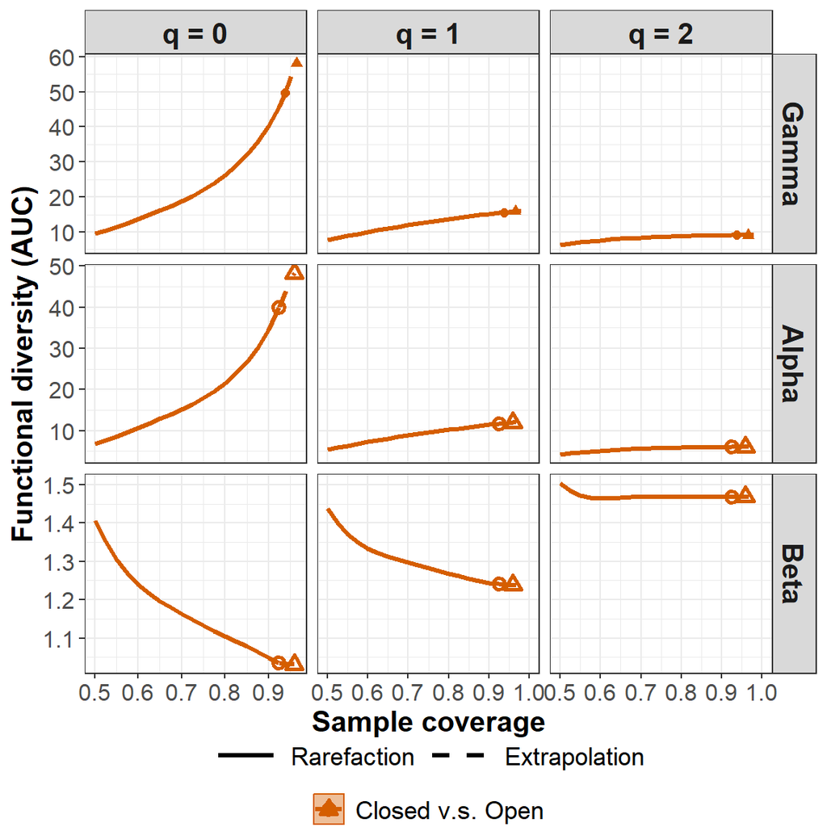

```r
## R/E curves for functional gamma, alpha and beta network diversity
ggiNEXTbeta.link(output_beta_qiFD, type = 'B')
```

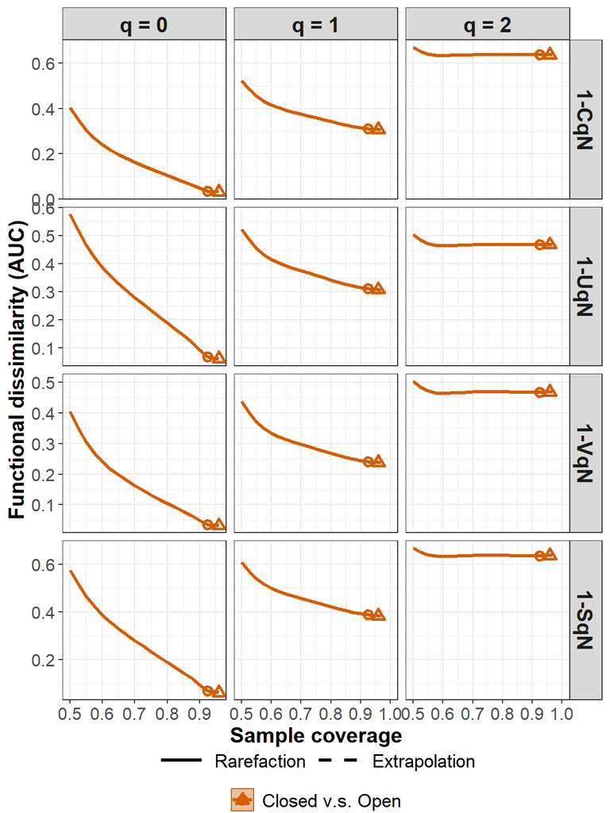

```r
## R/E curves for four functional network dissimilarity indices
ggiNEXTbeta.link(output_beta_qiFD, type = 'D')
```

## License

The iNEXT.link package is licensed under the GPLv3. To help refine `iNEXT.link`, your comments or feedback would be welcome (please send them to Anne Chao or report an issue on the iNEXT.link github [iNEXT.link_github](https://github.com/AnneChao/iNEXT.link).

## References

- Chiu, C.-H., Jost, L. and Chao*, A. (2014). Phylogenetic beta diversity, similarity, and differentiation measures based on Hill numbers. Ecological Monographs 84, 21-44.
- Chao, A., Chiu, C.-H., Villéger, S., Sun, I.-F., Thorn, S., Lin, Y.-C., Chiang, J. M. and Sherwin, W. B. (2019). An attribute-diversity approach to functional diversity, functional beta diversity, and related (dis)similarity measures. Ecological Monographs, 89, e01343. 10.1002/ecm.1343.
- Chao, A., Gotelli, N. J., Hsieh, T. C., Sander, E. L., Ma, K. H., Colwell, R. K. and Ellison, A. M. (2014). Rarefaction and extrapolation with Hill numbers: a framework for sampling and estimation in species diversity studies. Ecological Monographs, 84, 45–67.
- Chao, A., Henderson, P. A., Chiu, C.-H., Moyes, F., Hu, K.-H., Dornelas, M and Magurran, A. E. (2021). Measuring temporal change in alpha diversity: a framework integrating taxonomic, phylogenetic and functional diversity and the iNEXT.3D standardization. Methods in Ecology and Evolution, 12, 1926-1940.
- Chao, A. & Jost, L. (2012) Coverage-based rarefaction and extrapolation: standardizing samples by completeness rather than size. Ecology, 93, 2533–2547
- Chao, A., Thorn, S., Chiu, C.-H., Moyes, F., Hu, K.-H., Chazdon, R. L., Wu, J., Dornelas, M., Zeleny, D., Colwell, R. K., and Magurran, A. E. (2023). Rarefaction and extrapolation with beta diversity under a framework of Hill numbers: the iNEXT.beta3D standardization. Ecological Monographs, e1588.
- Chao, A., Y. Kubota, D. Zelený, C.-H. Chiu, C.-F. Li, B. Kusumoto, M. Yasuhara, S. Thorn, C.-L. Wei, M. J. Costello, and R. K. Colwell (2020). Quantifying sample completeness and comparing diversities among assemblages. Ecological Research, 35, 292-314.
- Chiu, C-H., Chao, A., Vogel, S., Kriegel, P. and Thorn, S. (2023). Quantifying and estimating ecological network diversity based on incomplete sampling data. Philosophical Transactions of the Royal Society B, 378: 20220183. https://doi.org/10.1098/rstb.2022.0183